# Data Science and Baseball

Through Machine Learning

# Fantasy Baseball Model Pitching 2022 Projections with Rank Worth

Darshan Patel

3/18/2022

### Load Libraries

```r
library(stringr)
library(sqldf)
library(rvest)
library(stringi)
library(skimr)
library(forcats)
library(ggplot2)
library(plyr)
library(dplyr)
library(tidyverse)
library(caret)
library(xgboost)
library(Matrix)
library(vtreat)
library(Boruta)
library(mgcv)
library(moments)
library(data.table)
library(pdp)
library(vip)
library(grid)
library(gridExtra)
library(janitor)
```

#### Team Stats from Fan-Graphs

##### Pitching stats from stat cast and supplemented by Fan-Graphs

```r
#https://www.fangraphs.com/leaders.aspx?pos=all&stats=pit&lg=all&qual=0&type=3&season=2021&month=0&season1=2015&ind=1&team=0,ts&rost=0&age=0&filter=&players=0&startdate=2015-01-01&enddate=2021-12-31


statcast_num = read_csv("Statcast_Num.csv")

statcast_ID = read_csv("Statcast_PitchingIdentification.csv")

FDG_AD = read_csv("FanGraphs Leaderboard_AuctionDol.csv")

FDG_PV = read_csv("FanGraphs Leaderboard_PitchValue.csv")

FDG_WinProb =read_csv("FanGraphs Leaderboard_WP.csv")

#Get Team Stats

setwd("C:\\Users\\Admin\\Documents\\Learning Python Folder1\\Fantasy Baseball Model\\Pitching\\Git_Files\\FanGraph Charts\\Team Stats")

FDG_T1 = read_csv("FanGraphs Leaderboard1.csv")

FDG_T2 = read_csv("FanGraphs Leaderboard2.csv")

FDG_T3 = read_csv("FanGraphs Leaderboard3.csv")

FDG_T4 = read_csv("FanGraphs Leaderboard4.csv")

FDG_T5 = read_csv("FanGraphs Leaderboard5.csv")

FDG_T6 = read_csv("FanGraphs Leaderboard6.csv")

FDG_T7 = read_csv("FanGraphs Leaderboard7.csv")
```

### Combine and Clean Player Data

```r
statcast_ID

library(dplyr)

statcast_ID2 = statcast_ID %>% dplyr::select(-player_id, -fg_PID)

#names(statcast_ID2)

Statcast_full = sqldf("
              select a.*, b.FanGraphID, b.Team,b.TEAM_ID
              from
              statcast_num a,
              statcast_ID2 b
              on a.Row_Column_Ind
                      =b.Row_Column_Ind
                      ")

#names(Statcast_full)

FDG_AD2 = FDG_AD %>% dplyr::select(-Season,-playerid,-Team)

FDG_PV2 = FDG_PV%>% dplyr::select(-Season,-playerid,-Team, -Name)

FDG_WinProb2 = FDG_WinProb %>% dplyr::select(-Season,-playerid,-Team,-Name)

Statcast_FGD = sqldf("
              select a.*, b.*, c.*,d.*
              from
              Statcast_full a
              left join
              FDG_AD2 b,
              FDG_PV2 c,
              FDG_WinProb2 d
              on a.FanGraphID = b.FanGraphID
              and a.FanGraphID = c.FanGraphID
              and a.FanGraphID = d.FanGraphID
                      ")
```

### Combine and Clean Team data

```r
FDG_Team = sqldf("
    select a.*,b.*,c.*,d.*,e.*,f.*,h.*
    from FDG_T1 a
    left join FDG_T2 b,FDG_T3 c,FDG_T4 d,
    FDG_T5 e, FDG_T6 f, FDG_T7 h
                on
                a.team = b.team
                and a.team = c.team
                and a.team = d.team
                and a.team = e.team
                and a.team = f.team
                and a.team = h.team
                and a.Season = b.Season
                and a.Season = c.Season
                and a.Season = d.Season
                and a.Season = e.Season
                and a.Season = f.Season
                and a.Season = h.Season
                 ")

FDG_Team2 <- FDG_Team[, !duplicated(colnames(FDG_Team))]

FDG_Team2 %>%
  group_by(Team) %>%
summarize(sum_W = sum(W))
```

| Team | sum_W |
| --- | --- |
| ARI | 485 |
| ATL | 517 |
| BAL | 423 |
| BOS | 572 |
| CHC | 576 |
| CHW | 483 |
| CIN | 456 |
| CLE | 576 |
| COL | 492 |
| DET | 435 |

[output cut: 20 more lines]

```r
require(DataCombine)

Replaces <-data.frame(from = c("KCR","SDP","TBR","SFG","CHW","WSN"), to = c("KC","SD","TB","SF","CWS","WAS"))

FDG_Team3 <- DataCombine::FindReplace(data = FDG_Team2, Var = "Team", replaceData = Replaces, from = "from", to = "to", exact = TRUE)
```

```
Only exact matches will be replaced.
```

```r
FDG_Team4 <- FDG_Team3 %>% rename_with( ~ paste0("T_", .x))

PF <- read_csv("Park_Factors.csv")
FDG_Team_PF <- sqldf("
select a.*,b.*
from FDG_Team4 a
left join PF b
on a.T_team = b.PF_Team
                     ")

Statcast_FGD2 <- Statcast_FGD %>% dplyr::select(-228,-230,-240,-255)

#names(Statcast_FGD)
```

### Final Dataset

|  | Row_Column_Ind | Max_stint | player_id | year | player_age | p_game | p_formatted_ip | p_total_pa | p_ab | p_total_hits | p_single | p_double | p_triple | p_home_run | p_strikeout | p_walk | p_k_percent | p_bb_percent | batting_avg | slg_percent | on_base_percent | on_base_plus_slg | isolated_power | p_earned_run | p_run | p_save | p_blown_save | p_out | p_win | … |
| --- | --- | --- | --- | --- | --- | --- | --- | --- | --- | --- | --- | --- | --- | --- | --- | --- | --- | --- | --- | --- | --- | --- | --- | --- | --- | --- | --- | --- | --- | --- |
| 1 | 1 | 1 | 554430 | 2021 | 31 | 32 | 213.1 | 849 | 785 | 169 | 121 | 29 | 3 | 16 | 247 | 46 | 29.1 | 5.4 | 0.215 | 0.321 | 0.263 | 0.584 | 0.106 | 66 | 72 | 0 | 0 | 640 | 14 | … |
| 2 | 2 | 1 | 554430 | 2020 | 30 | 11 | 71.0 | 288 | 264 | 67 | 48 | 16 | 0 | 3 | 53 | 16 | 18.4 | 5.6 | 0.254 | 0.348 | 0.313 | 0.661 | 0.094 | 23 | 26 | 0 | 0 | 213 | 4 | … |
| 3 | 3 | 1 | 554430 | 2019 | 29 | 31 | 195.1 | 828 | 760 | 196 | 140 | 33 | 1 | 22 | 195 | 50 | 23.6 | 6.0 | 0.258 | 0.391 | 0.300 | 0.690 | 0.133 | 86 | 93 | 0 | 0 | 586 | 11 | … |
| 4 | 4 | 1 | 554430 | 2018 | 28 | 29 | 182.1 | 744 | 668 | 150 | 115 | 20 | 1 | 14 | 179 | 55 | 24.1 | 7.4 | 0.225 | 0.320 | 0.288 | 0.608 | 0.095 | 67 | 69 | 0 | 0 | 547 | 12 | … |
| 5 | 5 | 1 | 554430 | 2017 | 27 | 17 | 86.1 | 386 | 342 | 97 | 66 | 15 | 1 | 15 | 81 | 40 | 21.0 | 10.4 | 0.284 | 0.465 | 0.363 | 0.828 | 0.181 | 50 | 53 | 0 | 0 | 259 | 3 | … |
| 6 | 6 | 1 | 641793 | 2021 | 26 | 63 | 61.2 | 252 | 222 | 46 | 25 | 12 | 2 | 7 | 63 | 24 | 25.0 | 9.5 | 0.207 | 0.374 | 0.286 | 0.660 | 0.167 | 20 | 24 | 2 | 4 | 185 | 4 | … |

#### Worth of each stat

```r
df_final_whip1 = df_final %>%
mutate(
  WHIP = (p_walk+p_total_hits)/p_formatted_ip,
  GS = ifelse(year == 2020, 60, 162),
  win_share_IP =ifelse(p_win < 1,0, (p_win/GS)),
  save_share_IP =ifelse(p_save < 1,0, (p_save/GS)),#/p_formatted_ip)),
  hold_share_IP =ifelse(p_hold < 1,0,  (p_hold/GS)),#/p_formatted_ip)),
  SO_share_IP = ifelse(p_strikeout < 1,0,(p_strikeout/GS)),#/p_formatted_ip)),
  WHIP_share_IP = ifelse(WHIP < 0.00001,0,((WHIP))),
  ERA_share_IP = ifelse(p_era < 0.00001,0, ((p_era)))
  )

df_rank_test= df_final_whip1 %>%
#  arrange(player_id,year) %>%
  group_by(year) %>%
  mutate(
    win_share = order(order(rank(win_share_IP,ties.method = 'average'),decreasing = FALSE))/n(),
     save_share = order(order(rank(save_share_IP,ties.method = 'average'),decreasing = FALSE))/n(),
     hold_share = order(order(rank(hold_share_IP,ties.method = 'average'),decreasing = FALSE))/n(),
     SO_share = order(order(rank(SO_share_IP,ties.method = 'average'),decreasing = FALSE))/n(),
     WHIP_share = order(order(rank(WHIP_share_IP,ties.method = 'average'),decreasing = FALSE))/n(),
     ERA_share = order(order(rank(ERA_share_IP,ties.method = 'average'),decreasing = FALSE))/n(),
    Worth = win_share+save_share+hold_share+SO_share+WHIP_share+ERA_share
    ) %>% select (Row_Column_Ind,player_id,year,Worth)


df_final_whipc_values =  df_final_whip1 %>%
#  arrange(player_id,year) %>%
  group_by(year) %>%
  mutate(
    win_share = order(order(rank(win_share_IP,ties.method = 'average'),decreasing = FALSE))/n(),
     save_share = order(order(rank(save_share_IP,ties.method = 'average'),decreasing = FALSE))/n(),
     hold_share = order(order(rank(hold_share_IP,ties.method = 'average'),decreasing = FALSE))/n(),
     SO_share = order(order(rank(SO_share_IP,ties.method = 'average'),decreasing = FALSE))/n(),
     WHIP_share = order(order(rank(WHIP_share_IP,ties.method = 'average'),decreasing = FALSE))/n(),
     ERA_share = order(order(rank(ERA_share_IP,ties.method = 'average'),decreasing = FALSE))/n(),
    Worth = win_share+save_share+hold_share+SO_share+WHIP_share+ERA_share
    ) %>% ungroup()
```

#### Checking for transformations

```r
#Exponent to 2 really normalizes the distribution

df_final_whipd_values = df_final_whipc_values %>%
  mutate(
    Worth = ((Worth)^(2))

  )

skewness((df_final_whipd_values$Worth))
```

```
[1] 0.1704845
```

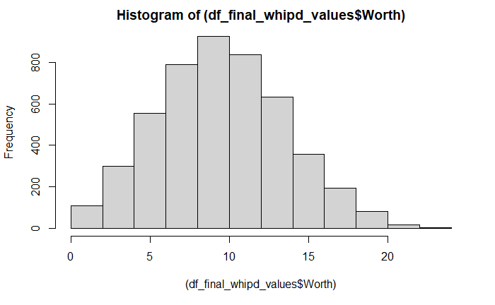

```r
hist((df_final_whipd_values$Worth))
```

```r
min(df_final_whipd_values$Worth)
```

```
[1] 0.04624202
```

```r
max(df_final_whipd_values$Worth)
```

```
[1] 22.78236
```

#### Lagging all Data

```r
df_final_whipe_values =  arrange(df_final_whipd_values, player_id,year  )

# Create lags of all data
DT = data.table(df_final_whipe_values)

cols1 = colnames(df_final_whipe_values)
anscols = paste("lag", cols1, sep="_")
DT[, (anscols) := data.table::shift(.SD, 1, NA, "lag"),by ='player_id', .SDcols=cols1]

df_final_whipf_values = as.data.frame(DT)

df_final_whipf_values$WorthF = (df_final_whipf_values$Worth)^(1)

ncol(df_final_whipe_values) #395 - no lags
```

```
[1] 395
```

```r
ncol(df_final_whipf_values) #791 - lagged data ~ (395 * 2) + 1
```

```
[1] 791
```

```r
#### Add indicators for Team - Consider changing player ID to factor

df_final_whipg_values = sqldf(
  "
  select a.*, b.TEAM_ID
  from df_final_whipf_values a,
  statcast_ID b
  on a.Team = b.Team
  and a.Row_Column_Ind = b.Row_Column_Ind
  "
)

head(df_final_whipg_values) # Final Large data set
```

|  | Row_Column_Ind | Max_stint | player_id | year | player_age | p_game | p_formatted_ip | p_total_pa | p_ab | p_total_hits | p_single | p_double | p_triple | p_home_run | p_strikeout | p_walk | p_k_percent | p_bb_percent | batting_avg | slg_percent | on_base_percent | on_base_plus_slg | isolated_power | p_earned_run | p_run | p_save | p_blown_save | p_out | p_win | … |
| --- | --- | --- | --- | --- | --- | --- | --- | --- | --- | --- | --- | --- | --- | --- | --- | --- | --- | --- | --- | --- | --- | --- | --- | --- | --- | --- | --- | --- | --- | --- |
| 1 | 4305 | 1 | 112526 | 2015 | 42 | 33 | 194.2 | 815 | 771 | 217 | 149 | 41 | 2 | 25 | 136 | 24 | 16.7 | 2.9 | 0.281 | 0.437 | 0.301 | 0.738 | 0.156 | 90 | 94 | 0 | 0 | 584 | 14 | … |
| 2 | 4304 | 1 | 112526 | 2016 | 43 | 34 | 191.2 | 791 | 745 | 200 | 134 | 36 | 6 | 24 | 128 | 32 | 16.2 | 4.0 | 0.268 | 0.430 | 0.297 | 0.727 | 0.162 | 73 | 81 | 0 | 0 | 575 | 15 | … |
| 3 | 4303 | 2 | 112526 | 2017 | 44 | 28 | 143.0 | 648 | 603 | 192 | 110 | 50 | 4 | 28 | 89 | 35 | 13.7 | 5.4 | 0.318 | 0.554 | 0.352 | 0.906 | 0.236 | 103 | 112 | 0 | 0 | 429 | 7 | … |
| 4 | 4302 | 1 | 112526 | 2018 | 45 | 28 | 146.1 | 628 | 591 | 172 | 95 | 35 | 10 | 32 | 81 | 25 | 12.9 | 4.0 | 0.291 | 0.547 | 0.318 | 0.865 | 0.256 | 94 | 97 | 0 | 0 | 439 | 7 | … |
| 5 | 1864 | 2 | 115629 | 2015 | 43 | 42 | 38.2 | 162 | 154 | 44 | 34 | 4 | 2 | 4 | 34 | 7 | 21.0 | 4.3 | 0.286 | 0.416 | 0.315 | 0.730 | 0.130 | 14 | 16 | 3 | 2 | 116 | 3 | … |
| 6 | 4089 | 1 | 136600 | 2015 | 38 | 2 | 6.1 | 35 | 34 | 17 | 11 | 3 | 0 | 3 | 4 | 1 | 11.4 | 2.9 | 0.500 | 0.853 | 0.514 | 1.367 | 0.353 | 9 | 9 | 0 | 0 | 19 | 0 | … |

```r
NA
```

#### Pare down variables

```r
df_final_whiph_values = df_final_whipg_values %>% distinct()

df_modelfile_initalt2021 = df_final_whiph_values %>%
    select(one_of(Col_to_keep_revised),p_gnd_into_dp,WPA,wFB) %>%
  mutate (
    WORTH = WorthF^1 ,
    T_Wavg = T_W/T_G,
    Lag_T_Wavg = lag_T_W/lag_T_G,
    T_BABIP_G = T_BABIP/T_G,
    lag_T_BABIP_G = lag_T_BABIP/T_G,
    factor_team = TEAM_ID,
    factor_year = as.factor(year),
    ###IP corrections
  pitchs_IP = (n / p_formatted_ip),
  fc_IP= (n_fc_formatted/p_formatted_ip),
  fs_IP =(n_fs_formatted/p_formatted_ip) ,
  kn_IP=   (n_kn_formatted/p_formatted_ip),
  fs_IP =  (n_fs_formatted/p_formatted_ip),
  fastball_IP =(n_fastball_formatted/p_formatted_ip),
  offspeed_IP=  (n_offspeed_formatted/p_formatted_ip),
  breaking_IP = (n_breaking_formatted/p_formatted_ip),
  p_run_support_IP=(p_run_support/p_formatted_ip),
  pitch_count_offspeed_IP=(pitch_count_offspeed/p_formatted_ip),
  pitch_count_fastball_IP=(pitch_count_fastball/p_formatted_ip),
  pitch_count_breaking_IP=(pitch_count_breaking/p_formatted_ip),
  n_ff_formatted_IP=(n_ff_formatted/p_formatted_ip),
  n_sl_formatted_IP=(n_sl_formatted/p_formatted_ip),
  n_ch_formatted_IP=(n_ch_formatted/p_formatted_ip),
  n_cukc_formatted_IP=(n_cukc_formatted/p_formatted_ip),
  n_sift_formatted_IP=(n_sift_formatted/p_formatted_ip),
  SD_IP = (SD/p_formatted_ip),
  MD_IP = (MD/p_formatted_ip),
  p_gnd_into_dp_IP = p_gnd_into_dp/p_formatted_ip,
  lag_p_total_hits_IP=(lag_p_total_hits/lag_p_formatted_ip),
  lag_p_home_run_IP=(lag_p_home_run/lag_p_formatted_ip),
  lag_p_strikeout_IP=(lag_p_strikeout/lag_p_formatted_ip),
  lag_p_walk_IP=(lag_p_walk/lag_p_formatted_ip),
  lag_p_earned_run_IP=(lag_p_earned_run/lag_p_formatted_ip),
  lag_p_run_IP=(lag_p_run/lag_p_formatted_ip),
  lag_p_save_IP=(lag_p_save/lag_p_formatted_ip),
  lag_p_blown_save_IP=(lag_p_blown_save/lag_p_formatted_ip),
  lag_p_out_IP=(lag_p_out/lag_p_formatted_ip),
  lag_p_win_IP=(lag_p_win/lag_p_formatted_ip),
  lag_p_loss_IP=(lag_p_loss/lag_p_formatted_ip),
  lag_p_wild_pitch_IP=(lag_p_wild_pitch/lag_p_formatted_ip),
  lag_p_balk_IP=(lag_p_balk/lag_p_formatted_ip),
  lag_p_shutout_IP=(lag_p_shutout/lag_p_formatted_ip),
  lag_p_rbi_IP=(lag_p_rbi/lag_p_formatted_ip),
  lag_p_quality_start_IP=(lag_p_quality_start/lag_p_formatted_ip),
  lag_p_run_support_IP=(lag_p_run_support/lag_p_formatted_ip),
  lag_p_ab_scoring_IP=(lag_p_ab_scoring/lag_p_formatted_ip),
  lag_p_automatic_ball_IP=(lag_p_automatic_ball/lag_p_formatted_ip),
  lag_p_ball_IP=(lag_p_ball/lag_p_formatted_ip),
  lag_p_called_strike_IP=(lag_p_called_strike/lag_p_formatted_ip),
  lag_p_complete_game_IP=(lag_p_complete_game/lag_p_formatted_ip),                                  lag_p_foul_IP=(lag_p_foul/lag_p_formatted_ip),
  lag_p_foul_tip_IP=(lag_p_foul_tip/lag_p_formatted_ip),
  lag_p_game_finished_IP=(lag_p_game_finished/lag_p_formatted_ip),
  lag_p_game_in_relief_IP=(lag_p_game_in_relief/lag_p_formatted_ip),
  lag_p_gnd_into_dp_IP=(lag_p_gnd_into_dp/lag_p_formatted_ip),
  lag_p_gnd_into_tp_IP=(lag_p_gnd_into_tp/lag_p_formatted_ip),
  lag_p_gnd_rule_double_IP=(lag_p_gnd_rule_double/lag_p_formatted_ip),
  lag_p_hit_by_pitch_IP=(lag_p_hit_by_pitch/lag_p_formatted_ip),
  lag_p_hit_fly_IP=(lag_p_hit_fly/lag_p_formatted_ip),
  lag_p_hit_ground_IP=(lag_p_hit_ground/lag_p_formatted_ip),
  lag_p_hit_line_drive_IP=(lag_p_hit_line_drive/lag_p_formatted_ip),
  lag_p_hit_into_play_IP=(lag_p_hit_into_play/lag_p_formatted_ip),
  lag_p_hit_scoring_IP=(lag_p_hit_scoring/lag_p_formatted_ip),
  lag_p_hold_IP=(lag_p_hold/lag_p_formatted_ip),
  lag_p_intent_ball_IP=(lag_p_intent_ball/lag_p_formatted_ip),
  lag_p_intent_walk_IP=(lag_p_intent_walk/lag_p_formatted_ip),
  lag_p_out_fly_IP=(lag_p_out_fly/lag_p_formatted_ip),
  lag_p_out_ground_IP=(lag_p_out_ground/lag_p_formatted_ip),
  lag_p_out_line_drive_IP=(lag_p_out_line_drive/lag_p_formatted_ip),
  lag_p_passed_ball_IP=(lag_p_passed_ball/lag_p_formatted_ip),
  lag_p_relief_no_out_IP=(lag_p_relief_no_out/lag_p_formatted_ip),
  lag_p_sac_bunt_IP=(lag_p_sac_bunt/lag_p_formatted_ip),
  lag_p_sac_fly_IP=(lag_p_sac_fly/lag_p_formatted_ip),
  lag_p_swinging_strike_IP=(lag_p_swinging_strike/lag_p_formatted_ip),
  lag_p_total_ball_IP=(lag_p_total_ball/lag_p_formatted_ip),
  lag_p_total_bases_IP=(lag_p_total_bases/lag_p_formatted_ip),
  lag_p_total_pitches_IP=(lag_p_total_pitches/lag_p_formatted_ip),
  lag_p_total_strike_IP=(lag_p_total_strike/lag_p_formatted_ip),
  lag_p_total_swinging_strike_IP=(lag_p_total_swinging_strike/lag_p_formatted_ip),
  lag_n_IP=(lag_n/lag_p_formatted_ip),
  lag_n_ff_formatted_IP=(lag_n_ff_formatted/lag_p_formatted_ip),
  lag_n_sl_formatted_IP=(lag_n_sl_formatted/lag_p_formatted_ip),
  lag_n_ch_formatted_IP=(lag_n_ch_formatted/lag_p_formatted_ip),
  lag_n_cukc_formatted_IP=(lag_n_cukc_formatted/lag_p_formatted_ip),
  lag_n_sift_formatted_IP=(lag_n_sift_formatted/lag_p_formatted_ip),
  lag_n_fc_formatted_IP=(lag_n_fc_formatted/lag_p_formatted_ip),
  lag_n_fs_formatted_IP=(lag_n_fs_formatted/lag_p_formatted_ip),
  lag_n_kn_formatted_IP=(lag_n_kn_formatted/lag_p_formatted_ip),
  lag_n_fastball_formatted_IP=(lag_n_fastball_formatted/lag_p_formatted_ip),
  lag_n_breaking_formatted_IP=(lag_n_breaking_formatted/lag_p_formatted_ip),
  lag_n_offspeed_formatted_IP=(lag_n_offspeed_formatted/lag_p_formatted_ip),
  lag_RAR_IP=(lag_RAR/lag_p_formatted_ip),
  lag_WAR_IP=(lag_WAR/lag_p_formatted_ip),
  lag_Pulls_IP=(lag_Pulls/lag_p_formatted_ip),
  lag_Clutch_IP=(lag_Clutch/lag_p_formatted_ip),
  lag_SD_IP=(lag_SD/lag_p_formatted_ip),
  lag_MD_IP=(lag_MD/lag_p_formatted_ip),
  #woba Lag calc
  lag_woba=(((lag_p_walk-lag_p_intent_walk)*0.690) + (0.722*lag_p_hit_by_pitch) +(0.89*lag_p_single)+(1.27*lag_p_double)+(1.69*lag_p_triple)+(2.1*lag_p_home_run) )/(lag_p_ab+lag_p_walk - lag_p_intent_walk + lag_p_sac_fly + lag_p_hit_by_pitch)
#Removing excess variables
) %>% select (-TEAM_ID,-WorthF,-Worth, -lag_T_W, -lag_T_G, -T_W, -T_G, -T_BABIP,-lag_T_BABIP,-year) %>% select (-p_run_support,
-pitch_count_offspeed,-pitch_count_fastball,-pitch_count_breaking,-n,-n_ff_formatted,-n_sl_formatted,-n_ch_formatted,
-n_cukc_formatted,
-n_sift_formatted,
-n_fc_formatted,
-n_fs_formatted,
-n_kn_formatted,
-n_fastball_formatted,
-n_breaking_formatted,
-n_offspeed_formatted,
-p_gnd_into_dp,
-lag_p_strikeout,
-lag_p_walk,
-lag_p_earned_run,
-lag_p_run,
-lag_p_save,
-lag_p_blown_save,
-lag_p_out,
-lag_p_win,
-lag_p_loss,
-lag_p_wild_pitch,
-lag_p_balk,
-lag_p_shutout,
-lag_p_rbi,
-lag_p_quality_start,
-lag_p_run_support,
-lag_p_ab_scoring,
-lag_p_automatic_ball,
-lag_p_ball,
-lag_p_called_strike,
-lag_p_complete_game,
-lag_p_foul,
-lag_p_foul_tip,
-lag_p_game_finished,
-lag_p_game_in_relief,
-lag_p_gnd_into_dp,
-lag_p_gnd_into_tp,
-lag_p_gnd_rule_double,
-lag_p_hit_by_pitch,
-lag_p_hit_fly,
-lag_p_hit_ground,
-lag_p_hit_line_drive,
-lag_p_hit_into_play,
-lag_p_hit_scoring,
-lag_p_hold,
-lag_p_intent_ball,
-lag_p_intent_walk,
-lag_p_out_fly,
-lag_p_out_ground,
-lag_p_out_line_drive,
-lag_p_passed_ball,
-lag_p_relief_no_out,
-lag_p_sac_bunt,
-lag_p_sac_fly,
-lag_p_swinging_strike,
-lag_p_total_ball,
-lag_p_total_bases,
-lag_p_total_pitches,
-lag_p_total_strike,
-lag_p_total_swinging_strike,
-lag_n,
-lag_n_ff_formatted,
-lag_n_sl_formatted,
-lag_n_ch_formatted,
-lag_n_cukc_formatted,
-lag_n_sift_formatted,
-lag_n_fc_formatted,
-lag_n_fs_formatted,
-lag_n_kn_formatted,
-lag_n_fastball_formatted,
-lag_n_breaking_formatted,
-lag_n_offspeed_formatted,
-lag_RAR,
-lag_WAR,
-lag_Pulls,
-lag_Clutch,
-lag_SD,
-lag_MD,
-lag_p_single,
-lag_p_double,
-lag_p_triple,
-SD,
-MD
) %>% select (#-(z_swing_percent:oz_contact_percent),-(meatball_swing_percent:iz_contact_percent),
            # -inLI, -pLI, -gmLI, -exLI) %>% select (
  #-RE24,-SD_IP,-MD_IP,
  -p_run_support_IP,-factor_year,-p_formatted_ip)



# Keep variables with enough values (Need 30% data coverage rate here)
dataremovealt2021 =
skim(df_modelfile_initalt2021) %>%
  dplyr::select(skim_type, skim_variable, complete_rate) %>%
  filter (complete_rate > 0.30)

#dataremovealt

colstokeep = as.data.frame(t(dataremovealt2021[,2]))

colstokeep [ nrow(colstokeep) + 1 , ] <- NA

colstokeep = header.true(colstokeep)

colstokeep2 = colnames(colstokeep)

df_modelfile_init2alt2021 = df_modelfile_initalt2021 %>%
  select(one_of(colstokeep2))
```

### Boosted Regression Tree Model Through XGBoost

```r
set.seed(15674)  # For reproducibility
# Create index for testing and training data
inTrain <- createDataPartition(y = df_modelfile_init2alt2021$WORTH, p = 0.80, list = FALSE)
# subset pitching data for training
tr_2021 <- df_modelfile_init2alt2021[inTrain,]
# subset the rest to test
te_2021 <- df_modelfile_init2alt2021[-inTrain,]

nrow(tr_2021)/nrow(df_modelfile_init2alt2021)
```

```
[1] 0.8
```

##### Convert the training and testing sets into DMatrixes: DMatrix is the recommended class in xgboost.

*cleaning documentations:* https://www.kaggle.com/pelkoja/visual-xgboost-tuning-with-caret

https://winvector.github.io/vtreat/index.html

```r
treat_plan_2021 <- vtreat::designTreatmentsZ(
  dframe = tr_2021, # training data
  varlist = colnames(tr_2021) %>% .[. != "hitting_score1"], # input variables = all training data columns, except random
  codeRestriction = c("clean", "isBAD", "lev"), # derived variables types (drop cat_P)
  verbose = FALSE) # suppress messages

#clean stands for cleaned numerical variable, isBAD indicates that a value replacement has occurred (which indicates a missing value in this case), and lev is a binary indicator whether a particular value of that categorical variable was present.

#### Checking Scoreframe

score_frame <- treat_plan_2021$scoreFrame %>%
  select(varName, origName, code)

head(score_frame)
```

|  | varName | origName | code |
| --- | --- | --- | --- |
| 1 | player_id | player_id | clean |
| 2 | player_age | player_age | clean |
| 3 | xwobacon | xwobacon | clean |
| 4 | xbacon | xbacon | clean |
| 5 | p_k_percent | p_k_percent | clean |
| 6 | p_bb_percent | p_bb_percent | clean |

```r
tr_treated_2021 <- vtreat::prepare(treat_plan_2021, tr_2021)
te_treated_2021 <- vtreat::prepare(treat_plan_2021, te_2021)


#tr_treated = tr
#te_treated = te

dim(tr_treated_2021) #note there are dummies for each player and team
```

```
[1] 3840  632
```

```r
#tr_holdout <- dplyr::sample_frac(tr_treated, 0.2)
#hid <- as.numeric(rownames(tr_holdout))
#tr_treated <- tr_treated[-hid, ]
```

### Boosted Regression Tree Model Through XGBoost

```r
set.seed(15674)  # For reproducibility
# Create index for testing and training data
inTrain <- createDataPartition(y = df_modelfile_init2alt2021$WORTH, p = 0.80, list = FALSE)
# subset pitching data for training
tr_2021 <- df_modelfile_init2alt2021[inTrain,]
# subset the rest to test
te_2021 <- df_modelfile_init2alt2021[-inTrain,]

nrow(tr_2021)/nrow(df_modelfile_init2alt2021)
```

```
[1] 0.8
```

##### Convert the training and testing sets into DMatrixes: DMatrix is the recommended class in xgboost.

*cleaning documentations:* https://www.kaggle.com/pelkoja/visual-xgboost-tuning-with-caret

https://winvector.github.io/vtreat/index.html

```r
treat_plan_2021 <- vtreat::designTreatmentsZ(
  dframe = tr_2021, # training data
  varlist = colnames(tr_2021) %>% .[. != "hitting_score1"], # input variables = all training data columns, except random
  codeRestriction = c("clean", "isBAD", "lev"), # derived variables types (drop cat_P)
  verbose = FALSE) # suppress messages

#clean stands for cleaned numerical variable, isBAD indicates that a value replacement has occurred (which indicates a missing value in this case), and lev is a binary indicator whether a particular value of that categorical variable was present.

#### Checking Scoreframe

score_frame <- treat_plan_2021$scoreFrame %>%
  select(varName, origName, code)

head(score_frame)
```

|  | varName | origName | code |
| --- | --- | --- | --- |
| 1 | player_id | player_id | clean |
| 2 | player_age | player_age | clean |
| 3 | xwobacon | xwobacon | clean |
| 4 | xbacon | xbacon | clean |
| 5 | p_k_percent | p_k_percent | clean |
| 6 | p_bb_percent | p_bb_percent | clean |

```r
tr_treated_2021 <- vtreat::prepare(treat_plan_2021, tr_2021)
te_treated_2021 <- vtreat::prepare(treat_plan_2021, te_2021)


#tr_treated = tr
#te_treated = te

dim(tr_treated_2021) #note there are dummies for each player and team
```

```
[1] 3840  632
```

```r
#tr_holdout <- dplyr::sample_frac(tr_treated, 0.2)
#hid <- as.numeric(rownames(tr_holdout))
#tr_treated <- tr_treated[-hid, ]
```

### Make sure hold out and training data distribution make sense - consider using SQRT of dependant in model

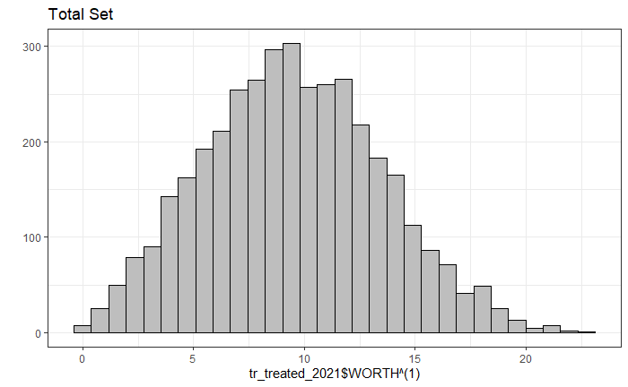

```r
#ggplot2::qplot(tr_holdout$WORTH, main="Hold-out Set") + geom_histogram(colour="black", fill="grey") + theme_bw()

ggplot2::qplot(tr_treated_2021$WORTH^(1), main="Total Set") + geom_histogram(colour="black", fill="grey") + theme_bw()
```

```r
#skewness(tr_holdout$WORTH)

skewness(tr_treated_2021$WORTH)
```

```
[1] 0.1638216
```

##### To keep things simple with modeling, we’ll turn the traninig data into simple input variables for `caret::train`, dropping the response variable and converting the data frame to a matrix:

```r
input_x <- as.matrix((select(tr_treated_2021, -WORTH, -lag_p_run_support_IP))%>%
   select(!ends_with ("_isBAD")))

input_y <- tr_treated_2021$WORTH
```

#### XGBoost with Default Hyperparameters

```r
grid_default <- expand.grid(
  nrounds = 100,
  max_depth = 6,
  eta = 0.3,
  gamma = 0,
  colsample_bytree = 1,
  min_child_weight = 1,
  subsample = 1
)

train_control <- caret::trainControl(
  method = "none",
  verboseIter = FALSE, # no training log
  allowParallel = TRUE # FALSE for reproducible results
)

xgb_base_2021 <- caret::train(
  x = input_x,
  y = input_y,
  trControl = train_control,
  tuneGrid = grid_default,
  method = "xgbTree",
  verbose = TRUE
)

varImp(xgb_base_2021, scale = F  ) #Note LI is leverage Index from Fan Graphs
```

```
xgbTree variable importance

  only 20 most important variables shown (out of 353)
```

|  | Overall |
| --- | --- |
| fastball_IP | 0.210689179 |
| RE24 | 0.127986147 |
| lag_save_share | 0.108512164 |
| gmLI | 0.038482976 |
| pitchs_IP | 0.034323876 |
| pLI | 0.031745699 |
| SD_IP | 0.027780894 |
| breaking_IP | 0.017830838 |
| MD_IP | 0.017270887 |
| lag_hold_share | 0.015791667 |

[output cut: 10 more lines]

```r
p1 = pdp::partial(
  xgb_base_2021,
  pred.var = "fastball_IP",
  ice = F,
  center = T,
  plot = T,
  alpha = .1,
  plot.engine = "ggplot2",
  train = tr_treated_2021 %>% select(-WORTH)
)


p2 = pdp::partial(
  xgb_base_2021,
  pred.var = "xwoba",
  ice = F,
  center = T,
  plot = T,
  alpha = .1,
  plot.engine = "ggplot2",
  train = tr_treated_2021 %>% select(-WORTH)
)

p3= pdp::partial(
  xgb_base_2021,
  pred.var = "pitchs_IP",
  ice = F,
  center = T,
  plot = T,
  alpha = .1,
  plot.engine = "ggplot2",
  train = tr_treated_2021 %>% select(-WORTH)
)


p4= pdp::partial(
  xgb_base_2021,
  pred.var = "lag_pLI",
  ice = F,
  center = T,
  plot = T,
  alpha = .1,
  plot.engine = "ggplot2",
  train = tr_treated_2021 %>% select(-WORTH)
)

grid.arrange
```

[output not shown]

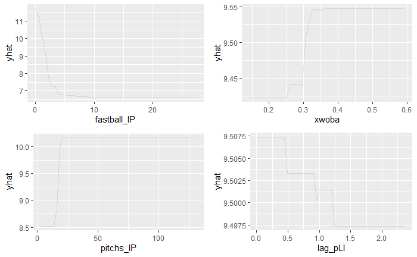

```r
grid.arrange(p1,p2,p3,p4)
```

##### Next, we build tuning grid for caret to explore between different hyperparameter values. To get started we’re using some suggestions from: https://www.slideshare.net/OwenZhang2/tips-for-data-science-competitions/14.

```r
defaultW <- getOption("warn")
options(warn = -1)



# maximum number of trees
nrounds <- 1000

# note to start nrounds from 200, as smaller learning rates result in errors so
# big with lower starting points that they'll mess the scales
tune_grid <- expand.grid(
  nrounds = seq(from = 200, to = nrounds, by = 50),
  eta = c(0.025, 0.05, 0.1,0.15, 0.2,0.25, 0.3),
  max_depth = c(2, 4, 6, 8, 10,12,14,16),
  gamma = 0,
  colsample_bytree = 1,
  min_child_weight = 1,
  subsample = 1
)

tune_control <- caret::trainControl(
  method = "cv", # cross-validation
  number = 5, # with n folds
  ## Note this was # out in the original code
  #index = createFolds(tr_treated$Id_clean), # fix the folds
  verboseIter = FALSE, # no training log
  allowParallel = TRUE # FALSE for reproducible results
)



xgb_tune_2021 <- caret::train(
  x = input_x,
  y = input_y,
  trControl = tune_control,
  tuneGrid = tune_grid,
  method = "xgbTree",
  verbose = FALSE
  ,verbosity = 0
)
options(warn = defaultW)

varImp(xgb_tune_2021, scale = F  )
```

```
xgbTree variable importance

  only 20 most important variables shown (out of 353)
```

|  | Overall |
| --- | --- |
| fastball_IP | 0.213317765 |
| RE24 | 0.133750374 |
| lag_save_share | 0.104071833 |
| pitchs_IP | 0.043028047 |
| gmLI | 0.042853533 |
| SD_IP | 0.039604171 |
| pLI | 0.036597406 |
| lag_hold_share | 0.029838079 |
| breaking_IP | 0.026419952 |
| MD_IP | 0.022023878 |

[output cut: 10 more lines]

#### plot for data

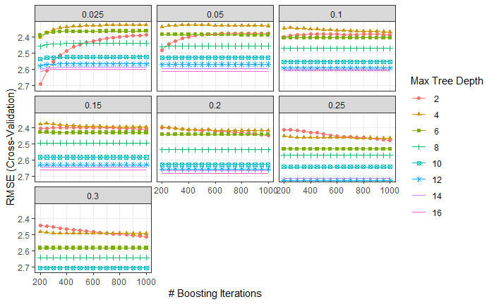

```r
# helper function for the plots
tuneplot <- function(x, probs = .90) {
  ggplot(x) +
    coord_cartesian(ylim = c(quantile(x$results$RMSE, probs = probs), min(x$results$RMSE))) +
    theme_bw()
}

tuneplot(xgb_tune_2021)
```

```r
xgb_tune_2021$bestTune
```

|  | nrounds | max_depth | eta | gamma | colsample_bytree | min_child_weight | subsample |
| --- | --- | --- | --- | --- | --- | --- | --- |
| 34 | 1000 | 4 | 0.025 | 0 | 1 | 1 | 1 |

```r
NA
```

#### Second Tuning: Maximum Depth and Minimum Child Weight

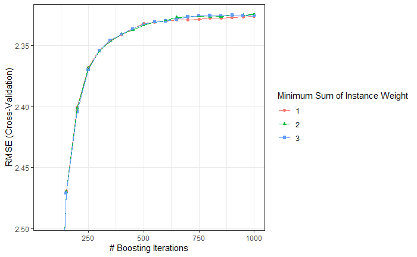

```r
tune_grid2 <- expand.grid(
  nrounds = seq(from = 50, to = nrounds, by = 50),
  eta = xgb_tune_2021$bestTune$eta,
  max_depth = ifelse(xgb_tune_2021$bestTune$max_depth == 2,
    c(xgb_tune_2021$bestTune$max_depth:4),
    xgb_tune_2021$bestTune$max_depth - 1:xgb_tune$bestTune$max_depth + 1),
  gamma = 0,
  colsample_bytree = 1,
  min_child_weight = c(1, 2, 3),
  subsample = 1
)

xgb_tune2_2021 <- caret::train(
  x = input_x,
  y = input_y,
  trControl = tune_control,
  tuneGrid = tune_grid2,
  method = "xgbTree",
  verbose = TRUE
)

tuneplot(xgb_tune2_2021)
```

```r
xgb_tune2_2021$bestTune
```

|  | nrounds | max_depth | eta | gamma | colsample_bytree | min_child_weight | subsample |
| --- | --- | --- | --- | --- | --- | --- | --- |
| 40 | 1000 | 4 | 0.025 | 0 | 1 | 2 | 1 |

```r
varImp(xgb_tune2_2021, scale = F  )
```

```
xgbTree variable importance

  only 20 most important variables shown (out of 353)
```

|  | Overall |
| --- | --- |
| fastball_IP | 0.213224700 |
| RE24 | 0.133338244 |
| lag_save_share | 0.103469490 |
| pitchs_IP | 0.042892764 |
| gmLI | 0.042321045 |
| SD_IP | 0.039817098 |
| pLI | 0.036652893 |
| lag_hold_share | 0.029962547 |
| breaking_IP | 0.026279498 |
| MD_IP | 0.022183967 |

[output cut: 10 more lines]

##### Third Tuning: Column and Row Sampling

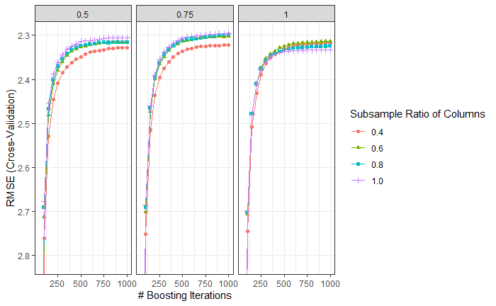

```r
tune_grid3 <- expand.grid(
  nrounds = seq(from = 50, to = nrounds, by = 50),
  eta = xgb_tune_2021$bestTune$eta,
  max_depth = xgb_tune2_2021$bestTune$max_depth,
  gamma = 0,
  colsample_bytree = c(0.4, 0.6, 0.8, 1.0),
  min_child_weight = xgb_tune2_2021$bestTune$min_child_weight,
  subsample = c(0.5, 0.75, 1.0)
)

xgb_tune3_2021 <- caret::train(
  x = input_x,
  y = input_y,
  trControl = tune_control,
  tuneGrid = tune_grid3,
  method = "xgbTree",
  verbose = TRUE
)

tuneplot(xgb_tune3_2021, probs = .95)
```

```r
xgb_tune3_2021$bestTune
```

|  | nrounds | max_depth | eta | gamma | colsample_bytree | min_child_weight | subsample |
| --- | --- | --- | --- | --- | --- | --- | --- |
| 220 | 1000 | 4 | 0.025 | 0 | 1 | 2 | 0.75 |

```r
varImp(xgb_tune3_2021, scale = F  )
```

```
xgbTree variable importance

  only 20 most important variables shown (out of 353)
```

|  | Overall |
| --- | --- |
| fastball_IP | 0.190283608 |
| RE24 | 0.120400092 |
| lag_save_share | 0.096871232 |
| pitchs_IP | 0.041482881 |
| SD_IP | 0.039316811 |
| gmLI | 0.036361761 |
| pLI | 0.030417481 |
| breaking_IP | 0.028059156 |
| lag_hold_share | 0.024824239 |
| MD_IP | 0.021055731 |

[output cut: 10 more lines]

##### Fourth Tuning: Gamma

Next, we again pick the best values from previous step, and now will see whether changing the gamma has any effect on the model fit:

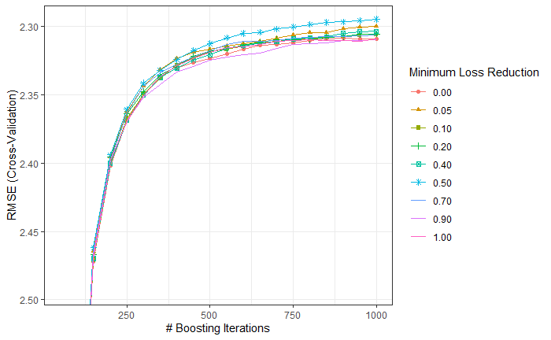

```r
tune_grid4 <- expand.grid(
  nrounds = seq(from = 50, to = nrounds, by = 50),
  eta = xgb_tune_2021$bestTune$eta,
  max_depth = xgb_tune2_2021$bestTune$max_depth,
  gamma = c(0, 0.05,0.1, 0.2,0.4, 0.5, 0.7, 0.9, 1.0),
  colsample_bytree = xgb_tune3_2021$bestTune$colsample_bytree,
  min_child_weight = xgb_tune2_2021$bestTune$min_child_weight,
  subsample = xgb_tune3_2021$bestTune$subsample
)

xgb_tune4_2021 <- caret::train(
  x = input_x,
  y = input_y,
  trControl = tune_control,
  tuneGrid = tune_grid4,
  method = "xgbTree",
  verbose = TRUE
)

tuneplot(xgb_tune4_2021)
```

```r
xgb_tune4_2021$bestTune
```

|  | nrounds | max_depth | eta | gamma | colsample_bytree | min_child_weight | subsample |
| --- | --- | --- | --- | --- | --- | --- | --- |
| 120 | 1000 | 4 | 0.025 | 0.5 | 1 | 2 | 0.75 |

```r
varImp(xgb_tune4_2021, scale = F  )
```

```
xgbTree variable importance

  only 20 most important variables shown (out of 353)
```

|  | Overall |
| --- | --- |
| fastball_IP | 0.186579068 |
| RE24 | 0.120223910 |
| lag_save_share | 0.096485729 |
| pitchs_IP | 0.040268206 |
| SD_IP | 0.037062356 |
| gmLI | 0.034754175 |
| pLI | 0.031797524 |
| breaking_IP | 0.025002767 |
| lag_hold_share | 0.024493567 |
| MD_IP | 0.023175298 |

[output cut: 10 more lines]

##### Fifth Tuning: Reducing the Learning Rate

Now, we have tuned the hyperparameters and can start reducing the learning rate to get to the final model:

```r
tune_grid5 <- expand.grid(
  nrounds = seq(from = 50, to = 15000, by = 100),
   eta = c(0.005, 0.01, 0.015, 0.025,0.035, 0.05,0.75, 0.1),
  max_depth = xgb_tune2_2021$bestTune$max_depth,
  gamma = xgb_tune4_2021$bestTune$gamma,
  colsample_bytree = xgb_tune3_2021$bestTune$colsample_bytree,
  min_child_weight = xgb_tune2_2021$bestTune$min_child_weight,
  subsample = xgb_tune3_2021$bestTune$subsample
)



xgb_tune5_2021 <- caret::train(
  x = input_x,
  y = input_y,
  trControl = tune_control,
  tuneGrid = tune_grid5,
  method = "xgbTree",
  verbose = TRUE
)

#tuneplot(xgb_tune5_2021)

xgb_tune5_2021$bestTune
```

|  | nrounds | max_depth | eta | gamma | colsample_bytree | min_child_weight | subsample |
| --- | --- | --- | --- | --- | --- | --- | --- |
| 193 | 4250 | 4 | 0.01 | 0.5 | 1 | 2 | 0.75 |

```r
varImp(xgb_tune5_2021, scale = F  )
```

```
xgbTree variable importance

  only 20 most important variables shown (out of 353)
```

|  | Overall |
| --- | --- |
| fastball_IP | 0.178351442 |
| RE24 | 0.112656780 |
| lag_save_share | 0.091918539 |
| pitchs_IP | 0.039592835 |
| gmLI | 0.038087138 |
| SD_IP | 0.035534374 |
| pLI | 0.027145777 |
| breaking_IP | 0.025091779 |
| lag_hold_share | 0.022872666 |
| MD_IP | 0.021120261 |

[output cut: 10 more lines]

#### Fitting Final Model

```r
(final_grid_2021 <- expand.grid(
  nrounds = xgb_tune5_2021$bestTune$nrounds,
  eta = xgb_tune5_2021$bestTune$eta,
  max_depth = xgb_tune5_2021$bestTune$max_depth,
  gamma = xgb_tune5_2021$bestTune$gamma,
  colsample_bytree = xgb_tune5_2021$bestTune$colsample_bytree,
  min_child_weight = xgb_tune5_2021$bestTune$min_child_weight,
  subsample = xgb_tune5_2021$bestTune$subsample
))
```

| nrounds | eta | max_depth | gamma | colsample_bytree | min_child_weight | subsample |
| --- | --- | --- | --- | --- | --- | --- |
| 4250 | 0.01 | 4 | 0.5 | 1 | 2 | 0.75 |

```r
(xgb_model_2021 <- caret::train(
  x = input_x,
  y = input_y,
  trControl = train_control,
  tuneGrid = final_grid_2021,
  method = "xgbTree",
  verbose = TRUE
))
```

```
eXtreme Gradient Boosting

3840 samples
 353 predictor

No pre-processing
Resampling: None
```

```r
varImp(xgb_model_2021, scale = F  )
```

```
xgbTree variable importance

  only 20 most important variables shown (out of 353)
```

|  | Overall |
| --- | --- |
| fastball_IP | 0.177870749 |
| RE24 | 0.111631780 |
| lag_save_share | 0.092272640 |
| pitchs_IP | 0.038983237 |
| SD_IP | 0.037383546 |
| gmLI | 0.034246549 |
| pLI | 0.028370510 |
| breaking_IP | 0.026486410 |
| lag_hold_share | 0.022952205 |
| MD_IP | 0.022614130 |

[output cut: 10 more lines]

#### Score model

```r
holdout_x <- select(tr_treated_2021, -WORTH)
holdout_y <- tr_treated_2021$WORTH

#(linear_base_rmse <- ModelMetrics::rmse(holdout_y, predict(linear_base, newdata = holdout_x)))

(xgb_base_rmse <- ModelMetrics::rmse(holdout_y, predict(xgb_base_2021, newdata = holdout_x)))
```

```
[1] 0.3213189
```

```r
(xgb_model_rmse <- ModelMetrics::rmse(holdout_y, predict(xgb_model_2021, newdata = holdout_x)))
```

```
[1] 0.7069686
```

#### Check on Test Data

```r
y_pred_test <- predict(xgb_model_2021, data.matrix(te_treated_2021))

test_stats= cbind((te_treated_2021$WORTH),y_pred_test)

test_statsR2 = cor(test_stats[,1],test_stats[,2])^2

print(test_statsR2)
```

```
[1] 0.6792509
```

```r
y_pred_train <- predict(xgb_model_2021, data.matrix(tr_treated_2021))

train_stats = cbind((tr_treated_2021$WORTH),y_pred_train)

train_statsR2 = cor(train_stats[,1],train_stats[,2])^2

print(train_statsR2)
```

```
[1] 0.9724109
```

```r
holdout_x <- select(te_treated_2021, -WORTH)
holdout_y <- (te_treated_2021$WORTH)

(xgb_model_rmse <- ModelMetrics::rmse(holdout_y, predict(xgb_model_2021, newdata = holdout_x)))
```

```
[1] 2.294431
```

```r
holdout_x <- select(tr_treated_2021, -WORTH)
holdout_y <- tr_treated_2021$WORTH

(xgb_model_rmse <- ModelMetrics::rmse(holdout_y, predict(xgb_model_2021, newdata = holdout_x)))
```

```
[1] 0.7069686
```

### Plot Train Results

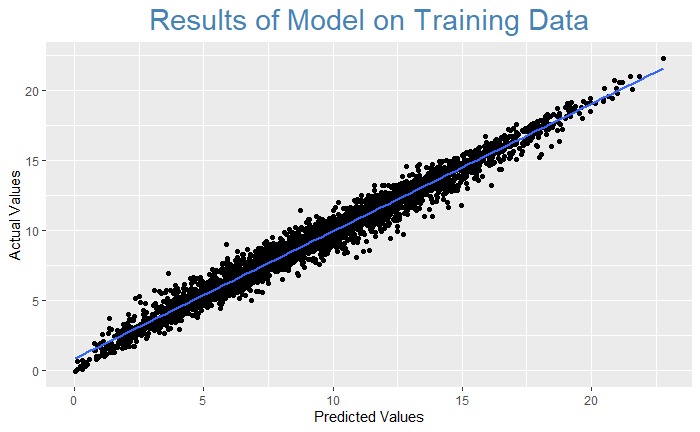

```r
par(mfrow=c(2,1))

ggplot2::ggplot() +
  aes(x = train_stats[,1], y = train_stats[,2]) +
  geom_jitter() +
  xlab("Predicted Values") +
  ylab("Actual Values") +
  ggtitle("Results of Model on Training Data")+
  theme(plot.title = element_text(hjust = 0.5,size = 22,color ="Steel Blue"))+
  geom_smooth(method = "lm")
```

### Plot Test Results

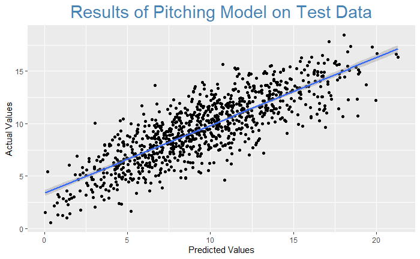

```r
ggplot2::ggplot() +
  aes(x = test_stats[,1], y = test_stats[,2]) +
  geom_jitter() +
  xlab("Predicted Values") +
  ylab("Actual Values") +
  ggtitle("Results of Pitching Model on Test Data")+
  theme(plot.title = element_text(hjust = 0.5,size = 22,color ="steel blue"))+
  geom_smooth(method = "lm")
```

## Creating Projections for 2022 Data

1. Only keep variables with high enough importance in model

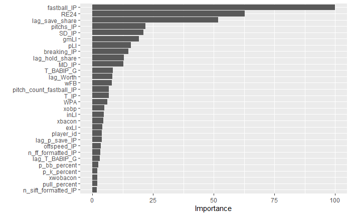

```r
library(janitor)

vip(xgb_model_2021, num_features = 30)  # 10 is the default
```

```r
unscalevi = vi(xgb_model_2021, method="model")

unscalevi$Importance_perc = with(unscalevi,Importance/sum(Importance))

variables_to_keep_2021 = subset(unscalevi, Importance_perc > 0.0025) %>% select(Variable)

variables_to_keep_2021b = t(variables_to_keep_2021)

variables_to_keep_2022 = colnames(row_to_names(variables_to_keep_2021b,row_number = 1))

tr_treated_2022 = tr_treated_2021 %>%  select(WORTH,one_of(variables_to_keep_2022))

te_treated_2022 = te_treated_2021 %>%  select(WORTH,one_of(variables_to_keep_2022))

input_x_2022 = as.matrix(select(tr_treated_2022, -WORTH))

input_y_2022 = tr_treated_2022$WORTH
```

2. Re-fit model

```r
(final_grid_2021 <- expand.grid(
  nrounds = xgb_tune5_2021$bestTune$nrounds,
  eta = xgb_tune5_2021$bestTune$eta,
  max_depth = xgb_tune5_2021$bestTune$max_depth,
  gamma = xgb_tune5_2021$bestTune$gamma,
  colsample_bytree = xgb_tune5_2021$bestTune$colsample_bytree,
  min_child_weight = xgb_tune5_2021$bestTune$min_child_weight,
  subsample = xgb_tune5_2021$bestTune$subsample
))
```

| nrounds | eta | max_depth | gamma | colsample_bytree | min_child_weight | subsample |
| --- | --- | --- | --- | --- | --- | --- |
| 4250 | 0.01 | 4 | 0.5 | 1 | 2 | 0.75 |

```r
(xgb_model_2022 <- caret::train(
  x = input_x_2022,
  y = input_y_2022,
  trControl = train_control,
  tuneGrid = final_grid_2021,
  method = "xgbTree",
  verbose = TRUE
))
```

```
eXtreme Gradient Boosting

3840 samples
  41 predictor

No pre-processing
Resampling: None
```

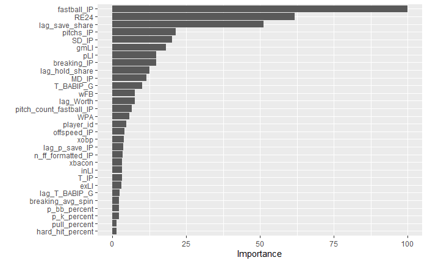

```r
vip(xgb_model_2022, num_features = 30)
```

```r
unscalevi24 = vi(xgb_model_2022, method="model")

unscalevi24$Importance_perc = with(unscalevi24,Importance/sum(Importance))

unscalevi24
```

| Variable | Importance | Importance_perc |
| --- | --- | --- |
| fastball_IP | 100.0000000 | 0.239101814 |
| RE24 | 61.8224561 | 0.147818614 |
| lag_save_share | 51.2245655 | 0.122478865 |
| pitchs_IP | 21.5135764 | 0.051439351 |
| SD_IP | 20.1286599 | 0.048127991 |
| gmLI | 18.1030759 | 0.043284783 |
| pLI | 14.8833981 | 0.035586475 |
| breaking_IP | 14.8765430 | 0.035570084 |
| lag_hold_share | 12.5187206 | 0.029932488 |
| MD_IP | 11.5132567 | 0.027528405 |

[output cut: 31 more lines]

```r
#For anything above breaking_IP we need to create projection table by age or age bucket

write_csv(unscalevi24,"unscalevi24.csv")
```

```
Error: Cannot open file for writing:
* 'C:\Users\Admin\Documents\Learning Python Folder1\Fantasy Baseball Model\Pitching\unscalevi24.csv'
```

#### Load in data for projections

```r
df_final_whipi_values =
df_final_whiph_values %>%
  group_by (player_id) %>%
  arrange(year) %>% slice_tail(n=1) %>% ungroup



df_proj_2022 = df_final_whipi_values %>%
  #  select(one_of(Col_to_keep_revised),p_total_swinging_strike,p_game_finished,p_save,p_quality_start,p_game_in_relief) %>%
  mutate (
    WORTH = WorthF^1 ,
    sqrt_lag_worth = ifelse(is.na(lag_Worth),NA, (lag_Worth)),
    T_Wavg = T_W/T_G,
    Lag_T_Wavg = lag_T_W/lag_T_G,
    T_BABIP_G = T_BABIP/T_G,
    lag_T_BABIP_G = lag_T_BABIP/T_G,
    factor_team = TEAM_ID,
    factor_year = year,
    ###IP corrections
  pitchs_IP = (n / p_formatted_ip),
  fc_IP= (n_fc_formatted/p_formatted_ip),
  fs_IP =(n_fs_formatted/p_formatted_ip) ,
  kn_IP=   (n_kn_formatted/p_formatted_ip),
  fs_IP =  (n_fs_formatted/p_formatted_ip),
  fastball_IP =(n_fastball_formatted/p_formatted_ip),
  offspeed_IP=  (n_offspeed_formatted/p_formatted_ip),
  breaking_IP = (n_breaking_formatted/p_formatted_ip),
  p_run_support_IP=(p_run_support/p_formatted_ip),
  pitch_count_offspeed_IP=(pitch_count_offspeed/p_formatted_ip),
  pitch_count_fastball_IP=(pitch_count_fastball/p_formatted_ip),
  pitch_count_breaking_IP=(pitch_count_breaking/p_formatted_ip),
  n_ff_formatted_IP=(n_ff_formatted/p_formatted_ip),
  n_sl_formatted_IP=(n_sl_formatted/p_formatted_ip),
  n_ch_formatted_IP=(n_ch_formatted/p_formatted_ip),
  n_cukc_formatted_IP=(n_cukc_formatted/p_formatted_ip),
  n_sift_formatted_IP=(n_sift_formatted/p_formatted_ip),
  SD_IP = (SD/p_formatted_ip),
  MD_IP = (MD/p_formatted_ip),
  lag_p_total_hits_IP=(lag_p_total_hits/lag_p_formatted_ip),
  lag_p_home_run_IP=(lag_p_home_run/lag_p_formatted_ip),
  lag_p_strikeout_IP=(lag_p_strikeout/lag_p_formatted_ip),
  lag_p_walk_IP=(lag_p_walk/lag_p_formatted_ip),
  lag_p_earned_run_IP=(lag_p_earned_run/lag_p_formatted_ip),
  lag_p_run_IP=(lag_p_run/lag_p_formatted_ip),
  lag_p_save_IP=(lag_p_save/lag_p_formatted_ip),
  lag_p_blown_save_IP=(lag_p_blown_save/lag_p_formatted_ip),
  lag_p_out_IP=(lag_p_out/lag_p_formatted_ip),
  lag_p_win_IP=(lag_p_win/lag_p_formatted_ip),
  lag_p_loss_IP=(lag_p_loss/lag_p_formatted_ip),
  lag_p_wild_pitch_IP=(lag_p_wild_pitch/lag_p_formatted_ip),
  lag_p_balk_IP=(lag_p_balk/lag_p_formatted_ip),
  lag_p_shutout_IP=(lag_p_shutout/lag_p_formatted_ip),
  lag_p_rbi_IP=(lag_p_rbi/lag_p_formatted_ip),
  lag_p_quality_start_IP=(lag_p_quality_start/lag_p_formatted_ip),
  lag_p_run_support_IP=(lag_p_run_support/lag_p_formatted_ip),
  lag_p_ab_scoring_IP=(lag_p_ab_scoring/lag_p_formatted_ip),
  lag_p_automatic_ball_IP=(lag_p_automatic_ball/lag_p_formatted_ip),
  lag_p_ball_IP=(lag_p_ball/lag_p_formatted_ip),
  lag_p_called_strike_IP=(lag_p_called_strike/lag_p_formatted_ip),
  lag_p_complete_game_IP=(lag_p_complete_game/lag_p_formatted_ip),                                  lag_p_foul_IP=(lag_p_foul/lag_p_formatted_ip),
  lag_p_foul_tip_IP=(lag_p_foul_tip/lag_p_formatted_ip),
  lag_p_game_finished_IP=(lag_p_game_finished/lag_p_formatted_ip),
  lag_p_game_in_relief_IP=(lag_p_game_in_relief/lag_p_formatted_ip),
  lag_p_gnd_into_dp_IP=(lag_p_gnd_into_dp/lag_p_formatted_ip),
  lag_p_gnd_into_tp_IP=(lag_p_gnd_into_tp/lag_p_formatted_ip),
  lag_p_gnd_rule_double_IP=(lag_p_gnd_rule_double/lag_p_formatted_ip),
  lag_p_hit_by_pitch_IP=(lag_p_hit_by_pitch/lag_p_formatted_ip),
  lag_p_hit_fly_IP=(lag_p_hit_fly/lag_p_formatted_ip),
  lag_p_hit_ground_IP=(lag_p_hit_ground/lag_p_formatted_ip),
  lag_p_hit_line_drive_IP=(lag_p_hit_line_drive/lag_p_formatted_ip),
  lag_p_hit_into_play_IP=(lag_p_hit_into_play/lag_p_formatted_ip),
  lag_p_hit_scoring_IP=(lag_p_hit_scoring/lag_p_formatted_ip),
  lag_p_hold_IP=(lag_p_hold/lag_p_formatted_ip),
  lag_p_intent_ball_IP=(lag_p_intent_ball/lag_p_formatted_ip),
  lag_p_intent_walk_IP=(lag_p_intent_walk/lag_p_formatted_ip),
  lag_p_out_fly_IP=(lag_p_out_fly/lag_p_formatted_ip),
  lag_p_out_ground_IP=(lag_p_out_ground/lag_p_formatted_ip),
  lag_p_out_line_drive_IP=(lag_p_out_line_drive/lag_p_formatted_ip),
  lag_p_passed_ball_IP=(lag_p_passed_ball/lag_p_formatted_ip),
  lag_p_relief_no_out_IP=(lag_p_relief_no_out/lag_p_formatted_ip),
  lag_p_sac_bunt_IP=(lag_p_sac_bunt/lag_p_formatted_ip),
  lag_p_sac_fly_IP=(lag_p_sac_fly/lag_p_formatted_ip),
  lag_p_swinging_strike_IP=(lag_p_swinging_strike/lag_p_formatted_ip),
  lag_p_total_ball_IP=(lag_p_total_ball/lag_p_formatted_ip),
  lag_p_total_bases_IP=(lag_p_total_bases/lag_p_formatted_ip),
  lag_p_total_pitches_IP=(lag_p_total_pitches/lag_p_formatted_ip),
  lag_p_total_strike_IP=(lag_p_total_strike/lag_p_formatted_ip),
  lag_p_total_swinging_strike_IP=(lag_p_total_swinging_strike/lag_p_formatted_ip),
  lag_n_IP=(lag_n/lag_p_formatted_ip),
  lag_n_ff_formatted_IP=(lag_n_ff_formatted/lag_p_formatted_ip),
  lag_n_sl_formatted_IP=(lag_n_sl_formatted/lag_p_formatted_ip),
  lag_n_ch_formatted_IP=(lag_n_ch_formatted/lag_p_formatted_ip),
  lag_n_cukc_formatted_IP=(lag_n_cukc_formatted/lag_p_formatted_ip),
  lag_n_sift_formatted_IP=(lag_n_sift_formatted/lag_p_formatted_ip),
  lag_n_fc_formatted_IP=(lag_n_fc_formatted/lag_p_formatted_ip),
  lag_n_fs_formatted_IP=(lag_n_fs_formatted/lag_p_formatted_ip),
  lag_n_kn_formatted_IP=(lag_n_kn_formatted/lag_p_formatted_ip),
  lag_n_fastball_formatted_IP=(lag_n_fastball_formatted/lag_p_formatted_ip),
  lag_n_breaking_formatted_IP=(lag_n_breaking_formatted/lag_p_formatted_ip),
  lag_n_offspeed_formatted_IP=(lag_n_offspeed_formatted/lag_p_formatted_ip),
  lag_RAR_IP=(lag_RAR/lag_p_formatted_ip),
  lag_WAR_IP=(lag_WAR/lag_p_formatted_ip),
  lag_Pulls_IP=(lag_Pulls/lag_p_formatted_ip),
  lag_Clutch_IP=(lag_Clutch/lag_p_formatted_ip),
  lag_SD_IP=(lag_SD/lag_p_formatted_ip),
  lag_MD_IP=(lag_MD/lag_p_formatted_ip),
  #woba Lag calc
  lag_woba=(((lag_p_walk-lag_p_intent_walk)*0.690) + (0.722*lag_p_hit_by_pitch) +(0.89*lag_p_single)+(1.27*lag_p_double)+(1.69*lag_p_triple)+(2.1*lag_p_home_run) )/(lag_p_ab+lag_p_walk - lag_p_intent_walk + lag_p_sac_fly + lag_p_hit_by_pitch)
#Removing excess variables
) %>%
  mutate(
    p_total_swinging_strike_IP = p_total_swinging_strike/p_formatted_ip,
    p_game_finished_IP = p_game_finished/p_formatted_ip,
   T_HR_slash_9 = 1, #df_final_whipi_values[['T_HR/9']],
    lag_T_HR_slash_9 = 2, #df_final_whipi_values[['lag_T_HR/9']],
    p_save_IP = p_save/p_formatted_ip,
    p_quality_start_IP = p_quality_start/p_formatted_ip,
   p_game_in_relief_IP =  p_game_in_relief/p_formatted_ip
   ) #%>%
 #select(one_of(variables_to_keep_2022),WORTH, factor_year, p_total_swinging_strike_IP,p_run_support_IP,p_save_IP,inLI,gmLI,SD_IP,pLI,T_IP,p_game_finished_IP,T_HR_slash_9, p_quality_start_IP, player_age,TEAM_ID,p_game_in_relief_IP) #additional identification variables


#names(df_final_whiph_values)


#skim(df_proj_2022)
```

#### xwoba projections - take1

```r
df_proj_2022_ref_table1 =  df_proj_2022 %>%
  group_by(player_age) %>%
  select(one_of(variables_to_keep_2022),player_age) %>%
  #summarise (xwoba_avg = mean(xwoba))
  summarise_at(vars(-group_cols()),mean,na.rm = TRUE)# %>%
#  select(-p_formatted_ip)

df_proj_2022_ref_table1 # There are some inconsistencies in the later ages
```

| player_age | fastball_IP | RE24 | lag_save_share | pitchs_IP | SD_IP | gmLI | pLI | breaking_IP | lag_hold_share | MD_IP | T_BABIP_G | lag_Worth | wFB | pitch_count_fastball_IP | T_IP | WPA | xobp | inLI | xbacon | exLI | player_id | lag_p_save_IP | offspeed_IP | n_ff_formatted_IP | lag_T_BABIP_G | p_bb_percent | p_k_percent | xwobacon | pull_percent | … |
| --- | --- | --- | --- | --- | --- | --- | --- | --- | --- | --- | --- | --- | --- | --- | --- | --- | --- | --- | --- | --- | --- | --- | --- | --- | --- | --- | --- | --- | --- | --- |
| 19 | 1.6656627 | 1.3800000 | NaN | 19.12651 | 0.03012048 | 0.2700000 | 0.2300000 | 0.76807229 | NaN | 0.09036145 | 0.0003984064 | NaN | -2.200000000 | 10.572289 | 1440.100 | -0.10000000 | 0.3790000 | 0.2300000 | 0.3170000 | 0.4000000 | 672773.0 | NaN | 0.57831325 | 1.6656627 | NaN | 15.100000 | 17.00000 | 0.3560000 | 34.30000 | … |
| 20 | 2.9347826 | 3.5400000 | NaN | 18.08696 | 0.30434783 | 1.1500000 | 1.2300000 | 1.37826087 | NaN | 0.17391304 | 0.0004241135 | NaN | -1.400000000 | 12.217391 | 1432.000 | 0.35000000 | 0.3010000 | 1.0700000 | 0.3250000 | 1.4500000 | 662253.0 | NaN | 0.03043478 | 2.8956522 | NaN | 11.300000 | 30.90000 | 0.3760000 | 17.90000 | … |
| 21 | 2.9424084 | -0.6600000 | 0.7094595 | 16.85864 | 0.10471204 | 0.7000000 | 0.6500000 | 1.38219895 | 0.4891892 | 0.05235602 | 0.0010431655 | 12.136749 | -4.300000000 | 9.476440 | 520.100 | -0.30000000 | 0.3110000 | 0.6900000 | 0.4110000 | 0.6300000 | 670970.0 | 0.00000000 | 0.91099476 | 2.9424084 | 0.0010755396 | 5.100000 | 31.60000 | 0.5100000 | 38.00000 | … |
| 22 | 2.7864006 | -2.4514286 | 0.3857282 | 16.96732 | 0.09017148 | 0.8450000 | 0.8314286 | 1.79812768 | 0.3931373 | 0.04366658 | 0.0004612706 | 9.592355 | -1.521428571 | 9.757224 | 1373.450 | -0.07571429 | 0.3220000 | 0.7907143 | 0.3221429 | 0.9650000 | 655986.5 | 0.00000000 | 0.40958945 | 2.0894776 | 0.0004187594 | 9.857143 | 23.62143 | 0.3775714 | 34.76429 | … |
| 23 | 3.6600231 | -1.6300000 | 0.4649006 | 17.65646 | 0.09361617 | 0.8552273 | 0.8606818 | 1.86997963 | 0.4229479 | 0.07581727 | 0.0004874523 | 6.629377 | -0.400000000 | 10.019101 | 1324.084 | -0.09250000 | 0.3510227 | 0.7952273 | 0.3289545 | 0.9297727 | 644121.2 | 0.01683156 | 0.95581442 | 2.7164701 | 0.0004424523 | 10.568182 | 17.92500 | 0.3762955 | 39.28864 | … |
| 24 | 3.3588447 | -1.8584058 | 0.4707720 | 18.14023 | 0.08200994 | 0.7871014 | 0.7734783 | 1.87878262 | 0.3571961 | 0.06435704 | 0.0004512264 | 8.382380 | -1.733333333 | 10.388520 | 1379.864 | -0.04797101 | 0.3448406 | 0.7149275 | 0.3305217 | 0.9050000 | 638630.9 | 0.02208647 | 0.84662142 | 2.4686816 | 0.0004609726 | 10.602899 | 19.79855 | 0.3780145 | 37.44928 | … |
| 25 | 3.4384173 | -3.0212319 | 0.4498137 | 17.84537 | 0.08322644 | 0.7753623 | 0.7622464 | 1.77689126 | 0.3783046 | 0.08366462 | 0.0004436812 | 8.699784 | -1.389855072 | 10.468595 | 1395.780 | -0.20992754 | 0.3430145 | 0.6979710 | 0.3268913 | 0.9053623 | 638854.9 | 0.02089159 | 0.80269294 | 2.2858026 | 0.0004479345 | 10.565217 | 19.95797 | 0.3714638 | 36.66884 | … |
| 26 | 3.7295927 | -2.4567614 | 0.4698010 | 18.37301 | 0.09198469 | 0.7859659 | 0.7464773 | 1.69848939 | 0.4380954 | 0.09887101 | 0.0004533833 | 8.443976 | -1.734482759 | 10.976135 | 1383.919 | -0.10289773 | 0.3519148 | 0.6800000 | 0.3350057 | 0.8421591 | 628449.7 | 0.01408302 | 0.72833602 | 2.8931049 | 0.0004564861 | 10.996591 | 19.65227 | 0.3867841 | 36.74148 | … |
| 27 | 3.0807342 | -2.0492614 | 0.4467868 | 17.94086 | 0.10821821 | 0.8161932 | 0.7954545 | 1.52406569 | 0.4727867 | 0.10760299 | 0.0004825397 | 8.478808 | -1.387500000 | 10.715201 | 1342.595 | -0.03880682 | 0.3452727 | 0.7272727 | 0.3316591 | 0.9189773 | 610645.5 | 0.01608348 | 0.63759785 | 2.0834060 | 0.0004989882 | 10.700568 | 20.11193 | 0.3799432 | 37.27330 | … |
| 28 | 3.0104903 | -1.6745062 | 0.4831362 | 17.75371 | 0.11507607 | 0.8693210 | 0.8158025 | 1.45843801 | 0.5158562 | 0.12550565 | 0.0004638218 | 9.505847 | -1.235185185 | 10.337011 | 1366.762 | -0.11351852 | 0.3425494 | 0.7479630 | 0.3340988 | 0.9132298 | 599737.3 | 0.02078497 | 0.77942571 | 2.0820822 | 0.0004657184 | 10.359877 | 20.72222 | 0.3838272 | 35.92778 | … |

[output cut: 16 more lines]

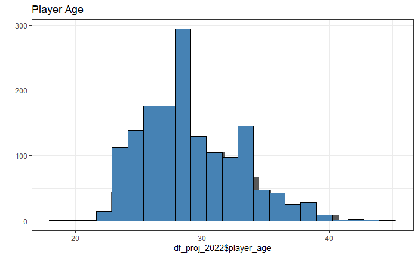

```r
#Histogram to get a sense of proper bins for age
ggplot2::qplot(df_proj_2022$player_age, main="Player Age") + geom_histogram(colour="black", fill="steel blue",bins = 22) + theme_bw()
```

```r
df_proj_2022 %>%
  group_by(player_age) %>%
  #summarise (xwoba_avg = mean(xwoba))
  count(player_age)
```

| player_age | n |
| --- | --- |
| 19 | 1 |
| 20 | 1 |
| 21 | 1 |
| 22 | 14 |
| 23 | 44 |
| 24 | 69 |
| 25 | 138 |
| 26 | 176 |
| 27 | 176 |
| 28 | 162 |

[output cut: 16 more lines]

```r
#younger than 24 = 23, and older than 33=34 can be the groupings


#write.csv(df_proj_2022_ref_table, "df_proj_ref_table.csv")
```

#### Re-adjust `player_age`

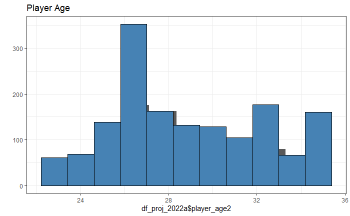

```r
df_proj_2022a = df_proj_2022 %>%
  mutate(
    player_age2 = ifelse(player_age <24|player_age > 34, ifelse(player_age <24,23,35) ,player_age)
  )


ggplot2::qplot(df_proj_2022a$player_age2, main="Player Age") + geom_histogram(colour="black", fill="steel blue",bins = 11) + theme_bw()
```

```r
df_proj_2022a %>%
  group_by(player_age2) %>%
  #summarise (xwoba_avg = mean(xwoba))
  count(player_age2)
```

| player_age2 | n |
| --- | --- |
| 23 | 61 |
| 24 | 69 |
| 25 | 138 |
| 26 | 176 |
| 27 | 176 |
| 28 | 162 |
| 29 | 132 |
| 30 | 129 |
| 31 | 105 |
| 32 | 97 |

[output cut: 3 more lines]

#### Average change by age_buckets (`player_age2`)

*Still need to condense further*

```r
df_proj_2022b = df_proj_2022 %>%
  mutate(
    player_age_test1 = ifelse(player_age <24|player_age > 34, ifelse(player_age <24,23,35) ,player_age) ,
  player_age2 = case_when(
    player_age_test1 < 24 ~ 1,
     player_age_test1 > 23 & player_age_test1 < 26 ~ 2,
           player_age_test1 > 25 & player_age_test1 < 28 ~ 3,
    player_age_test1 > 27 & player_age_test1 < 30 ~ 4,
             player_age_test1 > 29 & player_age_test1 < 32 ~ 5,
    TRUE ~ 6
      )
  )


df_proj_2022_ref_table2 =  df_proj_2022b %>%
  group_by(player_age2) %>%
  select(one_of(variables_to_keep_2022),player_age2) %>%
   select(!starts_with ("lag_")) %>%
  select(-player_id) %>%
  summarise_at(vars(-group_cols()),mean,na.rm = TRUE) #%>%
#  select(-p_formatted_ip)

df_proj_2022_ref_table2 # These will be the factor average for prediction of next year
```

| player_age2 | fastball_IP | RE24 | pitchs_IP | SD_IP | gmLI | pLI | breaking_IP | MD_IP | T_BABIP_G | wFB | pitch_count_fastball_IP | T_IP | WPA | xobp | inLI | xbacon | exLI | offspeed_IP | n_ff_formatted_IP | p_bb_percent | p_k_percent | xwobacon | pull_percent | n_sift_formatted_IP | meatball_swing_percent | hard_hit_percent | n_cukc_formatted_IP | opposite_percent | out_zone_percent | … |
| --- | --- | --- | --- | --- | --- | --- | --- | --- | --- | --- | --- | --- | --- | --- | --- | --- | --- | --- | --- | --- | --- | --- | --- | --- | --- | --- | --- | --- | --- | --- |
| 1 | 3.403172 | -1.6685246 | 17.51637 | 0.09542119 | 0.8455738 | 0.8462295 | 1.819368 | 0.06990037 | 0.0004880553 | -0.7672131 | 9.995208 | 1325.905 | -0.08491803 | 0.3433443 | 0.7877049 | 0.3284754 | 0.9327869 | 0.8147001 | 2.559410 | 10.401639 | 19.65410 | 0.3784426 | 37.79672 | 1.273982 | 76.75410 | 38.30984 | 0.8950419 | 25.71639 | 51.43934 | … |
| 2 | 3.411893 | -2.6336232 | 17.94366 | 0.08282094 | 0.7792754 | 0.7659903 | 1.810525 | 0.07722876 | 0.0004461963 | -1.5043478 | 10.441904 | 1390.475 | -0.15594203 | 0.3436232 | 0.7036232 | 0.3281014 | 0.9052427 | 0.8174949 | 2.346762 | 10.577778 | 19.90483 | 0.3736473 | 36.92899 | 1.594143 | 76.95797 | 36.63333 | 1.0245632 | 25.90145 | 52.19614 | … |
| 3 | 3.403299 | -2.2530114 | 18.15570 | 0.10010145 | 0.8010795 | 0.7709659 | 1.611023 | 0.10323700 | 0.0004679615 | -1.5600000 | 10.845668 | 1363.257 | -0.07085227 | 0.3485937 | 0.7036364 | 0.3333324 | 0.8805682 | 0.6829669 | 2.488255 | 10.848580 | 19.88210 | 0.3833636 | 37.00739 | 1.421550 | 77.00909 | 38.80057 | 0.7403115 | 25.58182 | 51.99318 | … |
| 4 | 3.082457 | -2.1036054 | 17.70073 | 0.11234702 | 0.8588776 | 0.8100340 | 1.578736 | 0.12056864 | 0.0004668781 | -1.6955782 | 10.255119 | 1365.811 | -0.13476190 | 0.3432755 | 0.7442517 | 0.3347075 | 0.9112287 | 0.7245419 | 2.029716 | 10.152041 | 20.34728 | 0.3855102 | 36.62007 | 1.365799 | 77.24116 | 38.44082 | 0.6508697 | 25.13299 | 51.96735 | … |
| 5 | 3.007401 | -0.9686325 | 17.56492 | 0.15273539 | 0.9137607 | 0.8609402 | 1.565747 | 0.13057472 | 0.0004497778 | -0.4326180 | 10.327699 | 1381.592 | 0.05679487 | 0.3346368 | 0.7866667 | 0.3279231 | 0.9507692 | 0.6890888 | 2.036998 | 9.909829 | 21.00641 | 0.3770427 | 37.42222 | 1.229081 | 76.78846 | 37.25085 | 0.8634845 | 25.14103 | 51.67009 | … |
| 6 | 2.699131 | -2.7635484 | 17.33624 | 0.14037592 | 0.9401737 | 0.9204963 | 1.366501 | 0.12159393 | 0.0004638895 | -1.8925000 | 10.262460 | 1370.402 | -0.16513648 | 0.3374665 | 0.8323325 | 0.3336476 | 1.0515212 | 0.6327322 | 1.450802 | 9.313896 | 19.86104 | 0.3830521 | 37.95360 | 1.324421 | 77.30248 | 37.55881 | 0.6637632 | 24.81960 | 52.16452 | … |

```r
NA
NA
NA
NA
NA
NA
NA
NA
NA
```

#### Getting Percentage changes in projects by age

```r
per_func = function(x) (lead(x, n = 1)/x)

#Create Indexes
df_proj_2022_ref_table3 =  df_proj_2022_ref_table2 %>%
  #group_by(player_age3) %>%
  arrange(player_age2, .by_group = TRUE) %>%
  mutate_at ((vars(-player_age2)),
    per_func
             )
#replace NAs with Index of 1
df_proj_2022_ref_table3[is.na(df_proj_2022_ref_table3)] <- 1

df_proj_2022_ref_table3
```

| player_age2 | fastball_IP | RE24 | pitchs_IP | SD_IP | gmLI | pLI | breaking_IP | MD_IP | T_BABIP_G | wFB | pitch_count_fastball_IP | T_IP | WPA | xobp | inLI | xbacon | exLI | offspeed_IP | n_ff_formatted_IP | p_bb_percent | p_k_percent | xwobacon | pull_percent | n_sift_formatted_IP | meatball_swing_percent | hard_hit_percent | n_cukc_formatted_IP | opposite_percent | out_zone_percent | … |
| --- | --- | --- | --- | --- | --- | --- | --- | --- | --- | --- | --- | --- | --- | --- | --- | --- | --- | --- | --- | --- | --- | --- | --- | --- | --- | --- | --- | --- | --- | --- |
| 1 | 1.0025627 | 1.5784144 | 1.0243934 | 0.8679512 | 0.9215936 | 0.9051804 | 0.9951399 | 1.1048406 | 0.9142329 | 1.9607952 | 1.0446910 | 1.0486988 | 1.8363830 | 1.0008124 | 0.8932573 | 0.9988615 | 0.9704711 | 1.0034305 | 0.9169152 | 1.0169337 | 1.0127573 | 0.9873289 | 0.977042 | 1.2513075 | 1.0026562 | 0.9562383 | 1.1447099 | 1.0071960 | 1.0147123 | … |
| 2 | 0.9974811 | 0.8554798 | 1.0118169 | 1.2086491 | 1.0279801 | 1.0064956 | 0.8898099 | 1.3367687 | 1.0487795 | 1.0369942 | 1.0386677 | 0.9804258 | 0.4543501 | 1.0144652 | 1.0000187 | 1.0159430 | 0.9727426 | 0.8354387 | 1.0602929 | 1.0256010 | 0.9988581 | 1.0260039 | 1.002123 | 0.8917332 | 1.0006643 | 1.0591602 | 0.7225630 | 0.9876597 | 0.9961117 | … |
| 3 | 0.9057262 | 0.9336861 | 0.9749410 | 1.1223316 | 1.0721501 | 1.0506742 | 0.9799584 | 1.1678821 | 0.9976848 | 1.0869091 | 0.9455498 | 1.0018733 | 1.9020124 | 0.9847437 | 1.0577221 | 1.0041253 | 1.0348190 | 1.0608740 | 0.8157184 | 0.9357945 | 1.0233968 | 1.0055993 | 0.989534 | 0.9607812 | 1.0030135 | 0.9907282 | 0.8791836 | 0.9824553 | 0.9995031 | … |
| 4 | 0.9756505 | 0.4604630 | 0.9923273 | 1.3594966 | 1.0639010 | 1.0628445 | 0.9917725 | 1.0829907 | 0.9633732 | 0.2551448 | 1.0070775 | 1.0115541 | -0.4214460 | 0.9748343 | 1.0569901 | 0.9797303 | 1.0433926 | 0.9510683 | 1.0035877 | 0.9761416 | 1.0323941 | 0.9780357 | 1.021905 | 0.8998992 | 0.9941392 | 0.9690443 | 1.3266625 | 1.0003196 | 0.9942798 | … |
| 5 | 0.8974962 | 2.8530412 | 0.9869809 | 0.9190792 | 1.0289058 | 1.0691757 | 0.8727474 | 0.9312211 | 1.0313747 | 4.3745288 | 0.9936830 | 0.9919005 | -2.9075948 | 1.0084562 | 1.0580498 | 1.0174570 | 1.1059689 | 0.9182157 | 0.7122254 | 0.9398644 | 0.9454753 | 1.0159382 | 1.014199 | 1.0775698 | 1.0066940 | 1.0082670 | 0.7687031 | 0.9872152 | 1.0095690 | … |
| 6 | 1.0000000 | 1.0000000 | 1.0000000 | 1.0000000 | 1.0000000 | 1.0000000 | 1.0000000 | 1.0000000 | 1.0000000 | 1.0000000 | 1.0000000 | 1.0000000 | 1.0000000 | 1.0000000 | 1.0000000 | 1.0000000 | 1.0000000 | 1.0000000 | 1.0000000 | 1.0000000 | 1.0000000 | 1.0000000 | 1.000000 | 1.0000000 | 1.0000000 | 1.0000000 | 1.0000000 | 1.0000000 | 1.0000000 | … |

```r
# adding suffix to column names
colnames(df_proj_2022_ref_table3) <- paste(colnames(df_proj_2022_ref_table3),"index",sep="_")

### For renaming if necessry,df_proj_2022_ref_table3 = df_proj_2022_ref_table3 %>% dplyr::rename(player_age2 = player_age2_index)


df_proj_2022c = df_proj_2022b %>%
#  filter(factor_year == 2021) %>%
  mutate(
    player_age_2022 = player_age + 1,
  player_age_test2 = ifelse(player_age_2022 <24|player_age_2022 > 34, ifelse(player_age_2022 <24,23,35) ,player_age_2022) ,
  player_age_2022_bucket = case_when(
    player_age_test2 < 24 ~ 1,
     player_age_test2 > 23 & player_age_test2 < 26 ~ 2,
      player_age_test2 > 25 & player_age_test2 < 28 ~ 3,
       player_age_test2 > 27 & player_age_test2 < 30 ~ 4,
        player_age_test2 > 29 & player_age_test2 < 32 ~ 5,
    TRUE ~ 6

      )
  )


colnames(df_proj_2022c) <- paste(colnames(df_proj_2022c),"2022",sep="_")

test_df_proj_2022c = df_proj_2022c %>% select (-WORTH_2022)


#names(df_proj_2022c)

df_proj_2022_ref_table3
```

| player_age2_index | fastball_IP_index | RE24_index | pitchs_IP_index | SD_IP_index | gmLI_index | pLI_index | breaking_IP_index | MD_IP_index | T_BABIP_G_index | wFB_index | pitch_count_fastball_IP_index | T_IP_index | WPA_index | xobp_index | inLI_index | xbacon_index | exLI_index | offspeed_IP_index | n_ff_formatted_IP_index | p_bb_percent_index | p_k_percent_index | xwobacon_index | pull_percent_index | n_sift_formatted_IP_index | meatball_swing_percent_index | hard_hit_percent_index | n_cukc_formatted_IP_index | opposite_percent_index | out_zone_percent_index | … |
| --- | --- | --- | --- | --- | --- | --- | --- | --- | --- | --- | --- | --- | --- | --- | --- | --- | --- | --- | --- | --- | --- | --- | --- | --- | --- | --- | --- | --- | --- | --- |
| 1 | 1.0025627 | 1.5784144 | 1.0243934 | 0.8679512 | 0.9215936 | 0.9051804 | 0.9951399 | 1.1048406 | 0.9142329 | 1.9607952 | 1.0446910 | 1.0486988 | 1.8363830 | 1.0008124 | 0.8932573 | 0.9988615 | 0.9704711 | 1.0034305 | 0.9169152 | 1.0169337 | 1.0127573 | 0.9873289 | 0.977042 | 1.2513075 | 1.0026562 | 0.9562383 | 1.1447099 | 1.0071960 | 1.0147123 | … |
| 2 | 0.9974811 | 0.8554798 | 1.0118169 | 1.2086491 | 1.0279801 | 1.0064956 | 0.8898099 | 1.3367687 | 1.0487795 | 1.0369942 | 1.0386677 | 0.9804258 | 0.4543501 | 1.0144652 | 1.0000187 | 1.0159430 | 0.9727426 | 0.8354387 | 1.0602929 | 1.0256010 | 0.9988581 | 1.0260039 | 1.002123 | 0.8917332 | 1.0006643 | 1.0591602 | 0.7225630 | 0.9876597 | 0.9961117 | … |
| 3 | 0.9057262 | 0.9336861 | 0.9749410 | 1.1223316 | 1.0721501 | 1.0506742 | 0.9799584 | 1.1678821 | 0.9976848 | 1.0869091 | 0.9455498 | 1.0018733 | 1.9020124 | 0.9847437 | 1.0577221 | 1.0041253 | 1.0348190 | 1.0608740 | 0.8157184 | 0.9357945 | 1.0233968 | 1.0055993 | 0.989534 | 0.9607812 | 1.0030135 | 0.9907282 | 0.8791836 | 0.9824553 | 0.9995031 | … |
| 4 | 0.9756505 | 0.4604630 | 0.9923273 | 1.3594966 | 1.0639010 | 1.0628445 | 0.9917725 | 1.0829907 | 0.9633732 | 0.2551448 | 1.0070775 | 1.0115541 | -0.4214460 | 0.9748343 | 1.0569901 | 0.9797303 | 1.0433926 | 0.9510683 | 1.0035877 | 0.9761416 | 1.0323941 | 0.9780357 | 1.021905 | 0.8998992 | 0.9941392 | 0.9690443 | 1.3266625 | 1.0003196 | 0.9942798 | … |
| 5 | 0.8974962 | 2.8530412 | 0.9869809 | 0.9190792 | 1.0289058 | 1.0691757 | 0.8727474 | 0.9312211 | 1.0313747 | 4.3745288 | 0.9936830 | 0.9919005 | -2.9075948 | 1.0084562 | 1.0580498 | 1.0174570 | 1.1059689 | 0.9182157 | 0.7122254 | 0.9398644 | 0.9454753 | 1.0159382 | 1.014199 | 1.0775698 | 1.0066940 | 1.0082670 | 0.7687031 | 0.9872152 | 1.0095690 | … |
| 6 | 1.0000000 | 1.0000000 | 1.0000000 | 1.0000000 | 1.0000000 | 1.0000000 | 1.0000000 | 1.0000000 | 1.0000000 | 1.0000000 | 1.0000000 | 1.0000000 | 1.0000000 | 1.0000000 | 1.0000000 | 1.0000000 | 1.0000000 | 1.0000000 | 1.0000000 | 1.0000000 | 1.0000000 | 1.0000000 | 1.000000 | 1.0000000 | 1.0000000 | 1.0000000 | 1.0000000 | 1.0000000 | 1.0000000 | … |

```r
df_proj_2022d = sqldf(
  "
  select a.*, b.* from test_df_proj_2022c a left join df_proj_2022_ref_table3 b
  on a.player_age2_2022 = b.player_age2_index
  "
)

WORTH_2022 = df_proj_2022c$WORTH_2022

names(WORTH_2022) = 'WORTH_2022'

test_df_proj_2022d = cbind(df_proj_2022d,WORTH_2022)
```

#### 2022 Dataset

```r
#Create 2022 Dataset
df_proj_2022e = test_df_proj_2022d %>%
  transmute(

player_id=player_id_2022,
fastball_IP= ifelse(player_age2_2022 == player_age_2022_bucket_2022,fastball_IP_2022,fastball_IP_2022*fastball_IP_index),
RE24= ifelse(player_age2_2022 == player_age_2022_bucket_2022,RE24_2022,RE24_2022*1),
lag_save_share=save_share_2022,
pitchs_IP= ifelse(player_age2_2022 == player_age_2022_bucket_2022,pitchs_IP_2022,pitchs_IP_2022*pitchs_IP_index),
SD_IP= ifelse(player_age2_2022 == player_age_2022_bucket_2022,SD_IP_2022,SD_IP_2022*SD_IP_index),
gmLI= ifelse(player_age2_2022 == player_age_2022_bucket_2022,gmLI_2022,gmLI_2022*1),
pLI= ifelse(player_age2_2022 == player_age_2022_bucket_2022,pLI_2022,pLI_2022*1),
breaking_IP= ifelse(player_age2_2022 == player_age_2022_bucket_2022,breaking_IP_2022,breaking_IP_2022*breaking_IP_index),
lag_hold_share=hold_share_2022,
MD_IP= ifelse(player_age2_2022 == player_age_2022_bucket_2022,MD_IP_2022,MD_IP_2022*MD_IP_index),
T_BABIP_G= ifelse(player_age2_2022 == player_age_2022_bucket_2022,T_BABIP_G_2022,T_BABIP_G_2022*T_BABIP_G_index),
wFB= ifelse(player_age2_2022 == player_age_2022_bucket_2022,wFB_2022,wFB_2022*1),
lag_Worth=Worth_2022,
pitch_count_fastball_IP= ifelse(player_age2_2022 == player_age_2022_bucket_2022,pitch_count_fastball_IP_2022,pitch_count_fastball_IP_2022*pitch_count_fastball_IP_index),
WPA= ifelse(player_age2_2022 == player_age_2022_bucket_2022,WPA_2022,WPA_2022*1),

offspeed_IP= ifelse(player_age2_2022 == player_age_2022_bucket_2022,offspeed_IP_2022,offspeed_IP_2022*offspeed_IP_index),
xobp= ifelse(player_age2_2022 == player_age_2022_bucket_2022,xobp_2022,xobp_2022*xobp_index),
lag_p_save_IP=p_save_IP_2022,
n_ff_formatted_IP= ifelse(player_age2_2022 == player_age_2022_bucket_2022,n_ff_formatted_IP_2022,n_ff_formatted_IP_2022*n_ff_formatted_IP_index),
xbacon= ifelse(player_age2_2022 == player_age_2022_bucket_2022,xbacon_2022,xbacon_2022*xbacon_index),
inLI= ifelse(player_age2_2022 == player_age_2022_bucket_2022,inLI_2022,inLI_2022*1),
T_IP= ifelse(player_age2_2022 == player_age_2022_bucket_2022,T_IP_2022,T_IP_2022*T_IP_index),
exLI= ifelse(player_age2_2022 == player_age_2022_bucket_2022,exLI_2022,exLI_2022*1),
lag_T_BABIP_G=T_BABIP_G_2022,
breaking_avg_spin= ifelse(player_age2_2022 == player_age_2022_bucket_2022,breaking_avg_spin_2022,breaking_avg_spin_2022*breaking_avg_spin_index),
p_bb_percent= ifelse(player_age2_2022 == player_age_2022_bucket_2022,p_bb_percent_2022,p_bb_percent_2022*p_bb_percent_index),
p_k_percent= ifelse(player_age2_2022 == player_age_2022_bucket_2022,p_k_percent_2022,p_k_percent_2022*p_k_percent_index),
pull_percent= ifelse(player_age2_2022 == player_age_2022_bucket_2022,pull_percent_2022,pull_percent_2022*pull_percent_index),
hard_hit_percent= ifelse(player_age2_2022 == player_age_2022_bucket_2022,hard_hit_percent_2022,hard_hit_percent_2022*hard_hit_percent_index),
n_sift_formatted_IP= ifelse(player_age2_2022 == player_age_2022_bucket_2022,n_sift_formatted_IP_2022,n_sift_formatted_IP_2022*n_sift_formatted_IP_index),
flyballs_percent= ifelse(player_age2_2022 == player_age_2022_bucket_2022,flyballs_percent_2022,flyballs_percent_2022*flyballs_percent_index),
meatball_swing_percent= ifelse(player_age2_2022 == player_age_2022_bucket_2022,meatball_swing_percent_2022,meatball_swing_percent_2022*meatball_swing_percent_index),
ff_avg_speed= ifelse(player_age2_2022 == player_age_2022_bucket_2022,ff_avg_speed_2022,ff_avg_speed_2022*ff_avg_speed_index),
out_zone_percent= ifelse(player_age2_2022 == player_age_2022_bucket_2022,out_zone_percent_2022,out_zone_percent_2022*out_zone_percent_index),
n_cukc_formatted_IP= ifelse(player_age2_2022 == player_age_2022_bucket_2022,n_cukc_formatted_IP_2022,n_cukc_formatted_IP_2022*n_cukc_formatted_IP_index),
T_HR_slash_9= ifelse(player_age2_2022 == player_age_2022_bucket_2022,T_HR_slash_9_2022,T_HR_slash_9_2022*T_HR_slash_9_index),
flareburner_percent= ifelse(player_age2_2022 == player_age_2022_bucket_2022,flareburner_percent_2022,flareburner_percent_2022*flareburner_percent_index),
pitch_count_breaking_IP= ifelse(player_age2_2022 == player_age_2022_bucket_2022,pitch_count_breaking_IP_2022,pitch_count_breaking_IP_2022*pitch_count_breaking_IP_index),
opposite_percent= ifelse(player_age2_2022 == player_age_2022_bucket_2022,opposite_percent_2022,opposite_percent_2022*opposite_percent_index),
xwobacon= ifelse(player_age2_2022 == player_age_2022_bucket_2022,xwobacon_2022,xwobacon_2022*xwobacon_index)





)


df_proj_2022e
```

| player_id | fastball_IP | RE24 | lag_save_share | pitchs_IP | SD_IP | gmLI | pLI | breaking_IP | lag_hold_share | MD_IP | T_BABIP_G | wFB | lag_Worth | pitch_count_fastball_IP | WPA | offspeed_IP | xobp | lag_p_save_IP | n_ff_formatted_IP | xbacon | inLI | T_IP | exLI | lag_T_BABIP_G | breaking_avg_spin | p_bb_percent | p_k_percent | pull_percent | hard_hit_percent | … |
| --- | --- | --- | --- | --- | --- | --- | --- | --- | --- | --- | --- | --- | --- | --- | --- | --- | --- | --- | --- | --- | --- | --- | --- | --- | --- | --- | --- | --- | --- | --- |
| 112526 | 0.55783710 | -14.19 | 0.702857143 | 15.249829 | 0.000000000 | 0.77 | 0.89 | 0.050650240 | 0.470000000 | 0.000000000 | 0.0004476048 | -11.6 | 16.36780408 | 12.429843 | -0.92 | 0.075975359 | 0.3290000 | 0.000000000 | 0.112251882 | 0.3440000 | 0.87 | 1431.0000 | 0.86 | 0.0004476048 | 2388.000 | 4.000000 | 12.900000 | 42.60000 | 40.50000 | … |
| 115629 | 1.97382199 | 3.84 | 0.906727829 | 14.476440 | 0.209424084 | 0.93 | 1.00 | 0.434554974 | 0.811926606 | 0.130890052 | 0.0004405705 | 1.0 | 11.85717626 | 10.916230 | 0.14 | 0.209424084 | 0.2810000 | 0.078534031 | 1.931937173 | 0.3210000 | 0.85 | 1441.0000 | 1.18 | 0.0004405705 | 2072.000 | 4.300000 | 21.000000 | 26.40000 | 38.80000 | … |
| 136600 | 7.50819672 | -5.96 | 0.681957187 | 19.344262 | 0.000000000 | 0.89 | 0.90 | 6.672131148 | 0.474006116 | 0.000000000 | 0.0004521193 | -3.0 | 11.26454236 | 8.852459 | -0.49 | 2.229508197 | 0.4310000 | 0.000000000 | 0.131147541 | 0.4730000 | 0.72 | 1432.2000 | 0.84 | 0.0004521193 | 2359.000 | 2.900000 | 11.400000 | 33.30000 | 46.70000 | … |
| 150116 | 1.42105263 | -9.67 | 0.163608563 | 18.099415 | 0.029239766 | 0.93 | 0.93 | 1.175438596 | 0.562691131 | 0.000000000 | 0.0004474474 | -9.3 | 8.48466038 | 8.801170 | -0.90 | 0.324561404 | 0.3760000 | 0.000000000 | 0.459064327 | 0.3800000 | 0.85 | 1447.0000 | 0.75 | 0.0004474474 | 2176.000 | 9.300000 | 17.400000 | 40.20000 | 41.00000 | … |
| 150274 | 9.57377049 | -0.92 | 0.414003044 | 20.491803 | 0.327868852 | 1.33 | 1.47 | 6.426229508 | 0.277016743 | 0.163934426 | 0.0003894166 | -0.4 | 3.65467313 | 11.967213 | -0.33 | 0.393442623 | 0.2700000 | 0.000000000 | 7.737704918 | 0.2370000 | 0.96 | 1460.1000 | 0.99 | 0.0003894166 | 2213.000 | 14.300000 | 32.100000 | 33.30000 | 33.30000 | … |
| 150302 | 1.26114650 | -14.86 | 0.426605505 | 16.411890 | 0.000000000 | 0.87 | 0.90 | 0.411889597 | 0.298165138 | 0.000000000 | 0.0004348463 | -10.6 | 12.13254589 | 9.745223 | -1.31 | 0.450106157 | 0.3200000 | 0.000000000 | NA | 0.3320000 | 0.78 | 1453.1000 | 0.60 | 0.0004348463 | 1977.000 | 6.500000 | 17.100000 | 40.20000 | 35.40000 | … |
| 150359 | 0.37682927 | 11.92 | 0.778287462 | 15.182927 | 0.000000000 | 0.87 | 1.04 | 0.179268293 | 0.541284404 | 0.000000000 | 0.0004561934 | 3.6 | 14.97713670 | 9.390244 | 1.95 | 0.053658537 | 0.3260000 | 0.000000000 | 0.071341463 | 0.3380000 | 0.91 | 1489.2000 | 1.20 | 0.0004561934 | 2023.000 | 7.000000 | 20.500000 | 40.30000 | 38.70000 | … |
| 217096 | 8.28571429 | -5.20 | 0.714067278 | 21.428571 | 0.000000000 | 0.65 | 0.84 | 2.857142857 | 0.492354740 | 0.000000000 | 0.0004453005 | -5.0 | 11.45004863 | 12.428571 | -0.41 | 3.142857143 | 0.4380000 | 0.000000000 | 4.285714286 | 0.3520000 | 0.81 | 1444.2000 | 1.38 | 0.0004453005 | 2738.000 | 16.200000 | 5.400000 | 41.40000 | 31.00000 | … |
| 218596 | 0.62662338 | -5.93 | 0.068807339 | 15.000000 | 0.000000000 | 0.83 | 1.00 | 0.094155844 | 0.051987768 | 0.000000000 | 0.0003936022 | -9.9 | 7.95861039 | 11.574675 | -0.61 | 0.090909091 | 0.3540000 | 0.000000000 | 0.056818182 | 0.3390000 | 0.92 | 1444.1000 | 1.45 | 0.0003936022 | 2260.000 | 7.000000 | 12.200000 | 40.30000 | 34.10000 | … |
| 234194 | 10.38750000 | -0.01 | 0.854740061 | 14.750000 | 0.500000000 | 1.65 | 1.23 | 1.700000000 | 0.733944954 | 0.125000000 | 0.0004451314 | 1.0 | 8.79022763 | 12.250000 | 0.60 | 0.425000000 | 0.2960000 | 0.125000000 | 7.312500000 | 0.3390000 | 0.93 | 1462.2000 | 1.35 | 0.0004451314 | 2000.000 | 3.100000 | 18.800000 | 28.00000 | 48.00000 | … |

[output cut: 990 more lines]

```r
NA
NA
NA
NA
NA
```

#### Create 2022 Projections - Filter where we have Player_ID

```r
FD_2022 = read_csv ("FanGraphs_2022.csv")
Players_2022 = FD_2022 %>% select (Name, Team, IP, ADP, fg_PID) %>% dplyr::rename(p_formatted_ip = IP) %>% mutate(year = 2022)

head(Players_2022)
```

| Name | Team | p_formatted_ip | ADP | fg_PID | year |
| --- | --- | --- | --- | --- | --- |
| Corbin Burnes | MIL | 171 | 11.4 | 19361 | 2022 |
| Zack Wheeler | PHI | 197 | 26.0 | 10310 | 2022 |
| Jacob deGrom | NYM | 142 | 22.8 | 10954 | 2022 |
| Gerrit Cole | NYY | 193 | 7.3 | 13125 | 2022 |
| Shane Bieber | CLE | 175 | 32.1 | 19427 | 2022 |
| Aaron Nola | PHI | 182 | 41.0 | 16149 | 2022 |

```r
head(statcast_ID)
```

| player_id | Row_Column_Ind | FanGraphID | last_name | first_name | Team | year | TEAM_ID | fg_PID |
| --- | --- | --- | --- | --- | --- | --- | --- | --- |
| 554430 | 1 | Zack Wheeler2021 | Wheeler | Zack | PHI | 2021 | 21 | 10310 |
| 554430 | 2 | Zack Wheeler2020 | Wheeler | Zack | PHI | 2020 | 21 | 10310 |
| 554430 | 3 | Zack Wheeler2019 | Wheeler | Zack | NYM | 2019 | 18 | 10310 |
| 554430 | 4 | Zack Wheeler2018 | Wheeler | Zack | NYM | 2018 | 18 | 10310 |
| 554430 | 5 | Zack Wheeler2017 | Wheeler | Zack | NYM | 2017 | 18 | 10310 |
| 641793 | 6 | Zack Littell2021 | Littell | Zack | SF | 2021 | 25 | 15823 |

```r
Players_2022b = sqldf(
  "
  select distinct a.Name,a.p_formatted_ip,a.ADP,b.player_id,a.Team, a.fg_PID from Players_2022 a
  left join statcast_ID b
  on a.fg_PID = b.fg_PID
  "
)

Players_2022c = Players_2022b %>%  filter (player_id!=(472610)& player_id!=(501992)& player_id!=(542866)) #|501992|542866))

#subset(df_final_whiph_values,player_id ==472610) #cut this one
#subset(df_final_whiph_values,player_id ==677651)
#subset(df_final_whiph_values,player_id ==450203)
#subset(df_final_whiph_values,player_id ==501992) #cut this one
#subset(df_final_whiph_values,player_id ==542866) # cut this one

subset(df_proj_2022e,player_id ==622663)
```

|  | player_id | fastball_IP | RE24 | lag_save_share | pitchs_IP | SD_IP | gmLI | pLI | breaking_IP | lag_hold_share | MD_IP | T_BABIP_G | wFB | lag_Worth | pitch_count_fastball_IP | WPA | offspeed_IP | xobp | lag_p_save_IP | n_ff_formatted_IP | xbacon | inLI | T_IP | exLI | lag_T_BABIP_G | breaking_avg_spin | p_bb_percent | p_k_percent | pull_percent | … |
| --- | --- | --- | --- | --- | --- | --- | --- | --- | --- | --- | --- | --- | --- | --- | --- | --- | --- | --- | --- | --- | --- | --- | --- | --- | --- | --- | --- | --- | --- | --- |
| 1072 | 622663 | 4.704786 | 4.93 | 0.2824324 | 18.46566 | 0 | 0.88 | 0.86 | 1.994657 | 0.1891892 | 0 | 0.000439093 | 3.7 | 1.224911 | 10.7329 | 0.35 | 1.141766 | 0.2962238 | 0 | 5.001048 | 0.2966554 | 0.76 | 1414.754 | 0.38 | 0.0004186704 | 2806.654 | 12.82001 | 35.35958 | 45.89723 | … |

```r
NA
NA
NA
```

#### Add the 2022 Projected Values and Create Predictions

```r
Player_2022d= sqldf(
  "
  select a.Name,a.p_formatted_ip, a.ADP, b.*
  from Players_2022c a
  left join df_proj_2022e b
  on a.player_id = b.player_id
  "
)

Player_2022e = Player_2022d %>% select(one_of(variables_to_keep_2022))
```

### Projections for Next year

```r
y_pred_2022 <- predict(xgb_model_2022, data.matrix(Player_2022e))

final_proj_w_hold = cbind(Player_2022d,y_pred_2022) %>% filter(ADP < 600)

final_proj_w_hold
```

| Name | p_formatted_ip | ADP | player_id | fastball_IP | RE24 | lag_save_share | pitchs_IP | SD_IP | gmLI | pLI | breaking_IP | lag_hold_share | MD_IP | T_BABIP_G | wFB | lag_Worth | pitch_count_fastball_IP | WPA | offspeed_IP | xobp | lag_p_save_IP | n_ff_formatted_IP | xbacon | inLI | T_IP | exLI | lag_T_BABIP_G | breaking_avg_spin | p_bb_percent | … |
| --- | --- | --- | --- | --- | --- | --- | --- | --- | --- | --- | --- | --- | --- | --- | --- | --- | --- | --- | --- | --- | --- | --- | --- | --- | --- | --- | --- | --- | --- | --- |
| Corbin Burnes | 171 | 11.4 | 669203 | 0.3411388 | 34.93 | 0.588390501 | 15.143694 | 0.000000000 | 0.87 | 1.00 | 0.160783586 | 0.420844327 | 0.000000000 | 0.0003947674 | -2.4 | 9.5300088 | 9.240343 | 3.31 | 0.060984373 | 0.2264911 | 0.000000000 | 0.007326812 | 0.2922005 | 0.97 | 1438.690 | 1.37 | 0.0003956835 | 2881.563 | 4.866131 | … |
| Zack Wheeler | 197 | 26.0 | 554430 | 0.2552242 | 39.57 | 0.001319261 | 14.844082 | 0.000000000 | 0.87 | 1.01 | 0.145799194 | 0.001319261 | 0.000000000 | 0.0004443769 | 26.0 | 4.8655746 | 9.055525 | 3.62 | 0.016373626 | 0.2672409 | 0.000000000 | 0.141709798 | 0.3194815 | 0.99 | 1406.713 | 1.25 | 0.0004308588 | 2461.323 | 5.075268 | … |
| Jacob deGrom | 142 | 22.8 | 594798 | 0.6239130 | 29.66 | 0.451187335 | 13.326087 | 0.000000000 | 0.88 | 0.93 | 0.366304348 | 0.331134565 | 0.000000000 | 0.0004070922 | 17.7 | 6.6316442 | 7.652174 | 2.89 | 0.096739130 | 0.1810000 | 0.000000000 | 0.623913043 | 0.2800000 | 0.98 | 1379.100 | 1.24 | 0.0004070922 | 2599.000 | 3.400000 | … |
| Gerrit Cole | 193 | 7.3 | 543037 | 0.2378786 | 27.04 | 0.484168865 | 16.180820 | 0.000000000 | 0.88 | 0.97 | 0.182645650 | 0.356200528 | 0.000000000 | 0.0004345852 | 12.1 | 10.1338911 | 7.813388 | 3.43 | 0.071997036 | 0.2591732 | 0.000000000 | 0.185233668 | 0.3316910 | 0.95 | 1423.476 | 1.19 | 0.0004213650 | 2677.912 | 5.263241 | … |
| Shane Bieber | 175 | 32.1 | 669456 | 0.4012474 | 13.96 | 0.110817942 | 16.205821 | 0.000000000 | 0.88 | 0.99 | 0.590436590 | 0.075197889 | 0.000000000 | 0.0004045911 | -4.0 | 5.8924680 | 6.247401 | 1.56 | 0.048856549 | 0.2950000 | 0.000000000 | 0.366943867 | 0.3520000 | 0.94 | 1408.000 | 1.36 | 0.0004045911 | 2519.000 | 8.100000 | … |
| Aaron Nola | 182 | 41.0 | 605400 | 0.2952275 | -1.27 | 0.725593668 | 16.487236 | 0.000000000 | 0.88 | 0.98 | 0.149833518 | 0.510554090 | 0.000000000 | 0.0004308588 | 4.9 | 15.2388263 | 8.773585 | -0.89 | 0.109877913 | 0.2730000 | 0.000000000 | 0.208102109 | 0.3270000 | 0.94 | 1418.200 | 1.10 | 0.0004308588 | 2529.000 | 5.200000 | … |
| Brandon Woodruff | 181 | 21.0 | 605540 | 0.3372418 | 39.72 | 0.654353562 | 15.689559 | 0.000000000 | 0.87 | 1.01 | 0.141261865 | 0.461741425 | 0.000000000 | 0.0003956835 | 22.7 | 9.9999460 | 9.480737 | 3.79 | 0.079285315 | 0.2810000 | 0.000000000 | 0.188163037 | 0.3340000 | 0.98 | 1436.000 | 1.15 | 0.0003956835 | 2614.000 | 6.100000 | … |
| Max Scherzer | 175 | 20.6 | 453286 | 0.3109994 | 38.94 | 0.228232190 | 15.750977 | 0.000000000 | 0.86 | 0.92 | 0.164154104 | 0.167546174 | 0.000000000 | 0.0003953488 | 19.9 | 6.1776512 | 8.777219 | 4.37 | 0.083193747 | 0.2490000 | 0.000000000 | 0.260748185 | 0.3090000 | 0.93 | 1394.100 | 1.04 | 0.0003953488 | 2403.000 | 5.200000 | … |
| Walker Buehler | 190 | 18.6 | 621111 | 0.2981203 | 43.32 | 0.031662269 | 14.831148 | 0.000000000 | 0.87 | 0.94 | 0.127697276 | 0.023746702 | 0.000000000 | 0.0003404174 | 22.9 | 4.7441208 | 9.816011 | 3.84 | 0.024576232 | 0.2698198 | 0.000000000 | 0.175190490 | 0.3052541 | 0.90 | 1454.720 | 1.08 | 0.0003412073 | 2845.355 | 5.989085 | … |
| Logan Webb | 171 | 69.5 | 657277 | 0.3280036 | 22.04 | 0.278364116 | 15.126013 | 0.008161034 | 0.89 | 0.96 | 0.166426289 | 0.548812665 | 0.000000000 | 0.0003845065 | 9.0 | 9.4568421 | 7.560323 | 2.19 | 0.133128659 | 0.2921660 | 0.000000000 | 0.070161181 | 0.3291655 | 0.92 | 1426.519 | 1.06 | 0.0003666229 | 2742.379 | 6.153606 | … |

[output cut: 327 more lines]

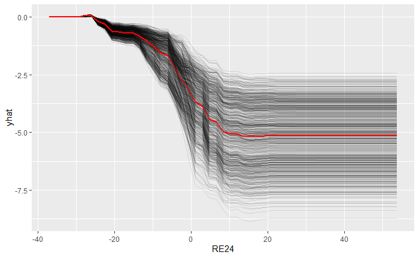

```r
p2 = pdp::partial(
  xgb_model_2022,
  pred.var = "RE24",
  ice = T,
  center = T,
  plot = T,
  alpha = .1,
  plot.engine = "ggplot2",
  train = Player_2022e# %>% select(-WORTH)
)
p2
```

```r
save(xgb_model_2022,file = "pitching_model2022wHRank.Rdata")
```